# 01_extra_cirricular_task

```python
pip install nbconvert PyPDF2
```

[output not shown]

[output not shown]

## Excercises

We've covered quite a bit, but now its time to build up your intuition and play around some more with what we've worked on.

Emphasis on the word play, as it's very important to try a few things out, run the code and see what happens.

1. Create your own regression dataset(or make the one we created in 'create data to view and fit' bigger) and fit a model to it.
2. Try building a neural network with 4 dense layers and fitting it to your own regression dataset, how does it perform?
3. Try and improve the results we got on the insurance dataset, some things you might want to try include:
- Building a larger model (how does one with 4 dense layers perform?)
- Increasing the number of units in each layer
- Lookup the documentation of `Adam` and find out what the first parameter is, what happens if you increase it by 10x?
- What happens if you train for longer (say 300 epochs instead of 200)?
4. Import the [Bostom pricing dataset](https://www.tensorflow.org/api_docs/python/tf/keras/datasets/boston_housing/load_data) from TensorFlow `tf.keras.datasets` and model it.

### Create dataset

I'm thinking of creating data thats a little more complex than `x = y+10`. I'm going to see if I can apply a sine wave on the data of y.

```python
# Make X dataset with 500 results
X = np.arange(-500, 1500)
X
```

```
array([-500, -499, -498, ..., 1497, 1498, 1499])
```

```python
# Make y dataset
y = (np.sin(X)*35) + (X/35) # a more complex y dataset, using sin on X multiplied by 35, along with increasing y by X/35
y
```

```
array([  2.0862989 , -31.44197953, -49.17059838, ...,  77.75450315,
        60.78562572,  27.28084695])
```

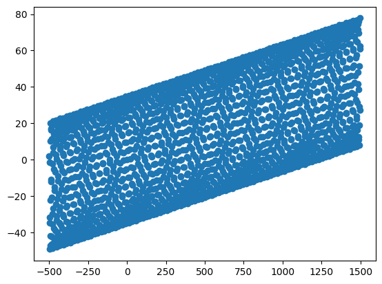

```python
# let's visualize the data we're working with
plt.scatter(X,y);
```

```python
# separate the data into training and test datasets
X_train = X[:1800] # total 2,000 data points, splitting 90/10 with train and test as this may be pretty complex for the model
y_train = y[:1800]

X_test = X[1800:]
y_test = y[1800:]

len(X_train), len(X_test)
```

```
(1800, 200)
```

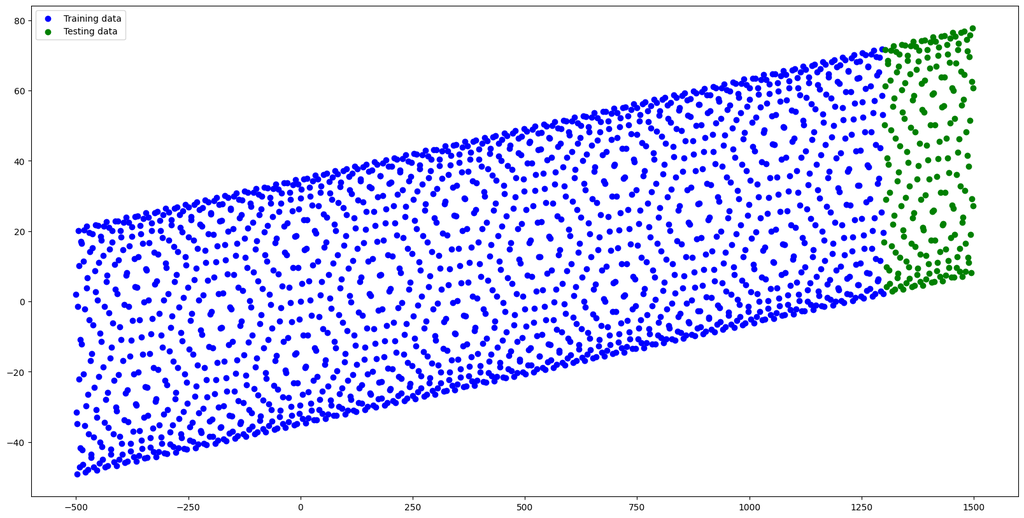

```python
# visualize the separate data of training and test in a graph
plt.figure(figsize=(20,10))
# plot training data in blue
plt.scatter(X_train, y_train, c='b', label='Training data')
# plot test data in green
plt.scatter(X_test, y_test, c='g', label='Testing data')
# Show the legend
plt.legend();
```

Now we've got our 2,000 datapoints, and have set up training and test datasets, we'll get to creating our ML model with 4 Dense layers.

```python
# Set seet
tf.random.set_seed(35)

# create model, with 4 layers
model = tf.keras.Sequential([
    tf.keras.layers.Dense(1000),
    tf.keras.layers.Dense(100),
    tf.keras.layers.Dense(10),
    tf.keras.layers.Dense(1)
])

# compile the model
model.compile(loss=tf.keras.losses.mae,
              optimizer=tf.keras.optimizers.SGD(),
              metrics=['mae'])

# fit model
model.fit(tf.expand_dims(X_train, axis=-1), y_train, epochs=100)
```

```
57/57 ━━━━━━━━━━━━━━━━━━━━ 1s 4ms/step - loss: nan - mae: nan
57/57 ━━━━━━━━━━━━━━━━━━━━ 0s 5ms/step - loss: nan - mae: nan
57/57 ━━━━━━━━━━━━━━━━━━━━ 0s 3ms/step - loss: nan - mae: nan
57/57 ━━━━━━━━━━━━━━━━━━━━ 0s 3ms/step - loss: nan - mae: nan
57/57 ━━━━━━━━━━━━━━━━━━━━ 0s 3ms/step - loss: nan - mae: nan
57/57 ━━━━━━━━━━━━━━━━━━━━ 0s 3ms/step - loss: nan - mae: nan
57/57 ━━━━━━━━━━━━━━━━━━━━ 0s 3ms/step - loss: nan - mae: nan
57/57 ━━━━━━━━━━━━━━━━━━━━ 0s 3ms/step - loss: nan - mae: nan
57/57 ━━━━━━━━━━━━━━━━━━━━ 0s 3ms/step - loss: nan - mae: nan
57/57 ━━━━━━━━━━━━━━━━━━━━ 0s 3ms/step - loss: nan - mae: nan
57/57 ━━━━━━━━━━━━━━━━━━━━ 0s 3ms/step - loss: nan - mae: nan
57/57 ━━━━━━━━━━━━━━━━━━━━ 0s 3ms/step - loss: nan - mae: nan
57/57 ━━━━━━━━━━━━━━━━━━━━ 0s 4ms/step - loss: nan - mae: nan
57/57 ━━━━━━━━━━━━━━━━━━━━ 0s 3ms/step - loss: nan - mae: nan
57/57 ━━━━━━━━━━━━━━━━━━━━ 0s 3ms/step - loss: nan - mae: nan
57/57 ━━━━━━━━━━━━━━━━━━━━ 0s 3ms/step - loss: nan - mae: nan
57/57 ━━━━━━━━━━━━━━━━━━━━ 0s 3ms/step - loss: nan - mae: nan
57/57 ━━━━━━━━━━━━━━━━━━━━ 0s 2ms/step - loss: nan - mae: nan
57/57 ━━━━━━━━━━━━━━━━━━━━ 0s 3ms/step - loss: nan - mae: nan
57/57 ━━━━━━━━━━━━━━━━━━━━ 0s 3ms/step - loss: nan - mae: nan
57/57 ━━━━━━━━━━━━━━━━━━━━ 0s 3ms/step - loss: nan - mae: nan
57/57 ━━━━━━━━━━━━━━━━━━━━ 0s 3ms/step - loss: nan - mae: nan
57/57 ━━━━━━━━━━━━━━━━━━━━ 0s 3ms/step - loss: nan - mae: nan
57/57 ━━━━━━━━━━━━━━━━━━━━ 0s 3ms/step - loss: nan - mae: nan
57/57 ━━━━━━━━━━━━━━━━━━━━ 0s 3ms/step - loss: nan - mae: nan
57/57 ━━━━━━━━━━━━━━━━━━━━ 0s 3ms/step - loss: nan - mae: nan
57/57 ━━━━━━━━━━━━━━━━━━━━ 0s 3ms/step - loss: nan - mae: nan
57/57 ━━━━━━━━━━━━━━━━━━━━ 0s 3ms/step - loss: nan - mae: nan
57/57 ━━━━━━━━━━━━━━━━━━━━ 0s 3ms/step - loss: nan - mae: nan
57/57 ━━━━━━━━━━━━━━━━━━━━ 0s 3ms/step - loss: nan - mae: nan
57/57 ━━━━━━━━━━━━━━━━━━━━ 0s 4ms/step - loss: nan - mae: nan
57/57 ━━━━━━━━━━━━━━━━━━━━ 0s 4ms/step - loss: nan - mae: nan
57/57 ━━━━━━━━━━━━━━━━━━━━ 0s 3ms/step - loss: nan - mae: nan
57/57 ━━━━━━━━━━━━━━━━━━━━ 0s 3ms/step - loss: nan - mae: nan
57/57 ━━━━━━━━━━━━━━━━━━━━ 0s 3ms/step - loss: nan - mae: nan
57/57 ━━━━━━━━━━━━━━━━━━━━ 0s 4ms/step - loss: nan - mae: nan
57/57 ━━━━━━━━━━━━━━━━━━━━ 0s 3ms/step - loss: nan - mae: nan
57/57 ━━━━━━━━━━━━━━━━━━━━ 0s 3ms/step - loss: nan - mae: nan
57/57 ━━━━━━━━━━━━━━━━━━━━ 0s 3ms/step - loss: nan - mae: nan
57/57 ━━━━━━━━━━━━━━━━━━━━ 0s 3ms/step - loss: nan - mae: nan
```

[output cut: 45 more lines]

```
57/57 ━━━━━━━━━━━━━━━━━━━━ 0s 3ms/step - loss: nan - mae: nan
57/57 ━━━━━━━━━━━━━━━━━━━━ 0s 3ms/step - loss: nan - mae: nan
57/57 ━━━━━━━━━━━━━━━━━━━━ 0s 3ms/step - loss: nan - mae: nan
57/57 ━━━━━━━━━━━━━━━━━━━━ 0s 3ms/step - loss: nan - mae: nan
57/57 ━━━━━━━━━━━━━━━━━━━━ 0s 3ms/step - loss: nan - mae: nan
57/57 ━━━━━━━━━━━━━━━━━━━━ 0s 3ms/step - loss: nan - mae: nan
57/57 ━━━━━━━━━━━━━━━━━━━━ 0s 3ms/step - loss: nan - mae: nan
57/57 ━━━━━━━━━━━━━━━━━━━━ 0s 3ms/step - loss: nan - mae: nan
57/57 ━━━━━━━━━━━━━━━━━━━━ 0s 3ms/step - loss: nan - mae: nan
57/57 ━━━━━━━━━━━━━━━━━━━━ 0s 5ms/step - loss: nan - mae: nan
57/57 ━━━━━━━━━━━━━━━━━━━━ 0s 3ms/step - loss: nan - mae: nan
57/57 ━━━━━━━━━━━━━━━━━━━━ 0s 3ms/step - loss: nan - mae: nan
57/57 ━━━━━━━━━━━━━━━━━━━━ 0s 3ms/step - loss: nan - mae: nan
57/57 ━━━━━━━━━━━━━━━━━━━━ 0s 3ms/step - loss: nan - mae: nan
57/57 ━━━━━━━━━━━━━━━━━━━━ 0s 3ms/step - loss: nan - mae: nan
```

```
<keras.src.callbacks.history.History at 0x2677f651b50>
```

Hmmmm strange that its only returning nan value, despite executing properly. Let's see if it could be because of the layers in our model causing the issue.

```python
# Set seet
tf.random.set_seed(35)

# create model, with 4 layers
model = tf.keras.Sequential([
    tf.keras.layers.Dense(1)
])

# compile the model
model.compile(loss=tf.keras.losses.mae,
              optimizer=tf.keras.optimizers.SGD(),
              metrics=['mae'])

# fit model
model.fit(tf.expand_dims(X_train, axis=-1), y_train, epochs=100)
```

```
57/57 ━━━━━━━━━━━━━━━━━━━━ 1s 2ms/step - loss: 1346.3323 - mae: 1346.3323
57/57 ━━━━━━━━━━━━━━━━━━━━ 0s 2ms/step - loss: 1436.5577 - mae: 1436.5577
57/57 ━━━━━━━━━━━━━━━━━━━━ 0s 2ms/step - loss: 1470.9430 - mae: 1470.9430
57/57 ━━━━━━━━━━━━━━━━━━━━ 0s 2ms/step - loss: 1470.5237 - mae: 1470.5237
57/57 ━━━━━━━━━━━━━━━━━━━━ 0s 2ms/step - loss: 1471.6185 - mae: 1471.6185
57/57 ━━━━━━━━━━━━━━━━━━━━ 0s 2ms/step - loss: 1469.8169 - mae: 1469.8169
57/57 ━━━━━━━━━━━━━━━━━━━━ 0s 2ms/step - loss: 1471.5468 - mae: 1471.5468
57/57 ━━━━━━━━━━━━━━━━━━━━ 0s 2ms/step - loss: 1469.7452 - mae: 1469.7452
57/57 ━━━━━━━━━━━━━━━━━━━━ 0s 2ms/step - loss: 1471.4750 - mae: 1471.4750
57/57 ━━━━━━━━━━━━━━━━━━━━ 0s 2ms/step - loss: 1469.6735 - mae: 1469.6735
57/57 ━━━━━━━━━━━━━━━━━━━━ 0s 2ms/step - loss: 1471.4442 - mae: 1471.4442
57/57 ━━━━━━━━━━━━━━━━━━━━ 0s 2ms/step - loss: 1470.9786 - mae: 1470.9786
57/57 ━━━━━━━━━━━━━━━━━━━━ 0s 3ms/step - loss: 1470.5596 - mae: 1470.5596
57/57 ━━━━━━━━━━━━━━━━━━━━ 0s 3ms/step - loss: 1471.6541 - mae: 1471.6541
57/57 ━━━━━━━━━━━━━━━━━━━━ 0s 3ms/step - loss: 1469.8527 - mae: 1469.8527
57/57 ━━━━━━━━━━━━━━━━━━━━ 0s 2ms/step - loss: 1471.5824 - mae: 1471.5824
57/57 ━━━━━━━━━━━━━━━━━━━━ 0s 2ms/step - loss: 1469.7809 - mae: 1469.7809
57/57 ━━━━━━━━━━━━━━━━━━━━ 0s 3ms/step - loss: 1471.5107 - mae: 1471.5107
57/57 ━━━━━━━━━━━━━━━━━━━━ 0s 2ms/step - loss: 1469.7095 - mae: 1469.7095
57/57 ━━━━━━━━━━━━━━━━━━━━ 0s 4ms/step - loss: 1471.4799 - mae: 1471.4799
57/57 ━━━━━━━━━━━━━━━━━━━━ 0s 2ms/step - loss: 1471.0142 - mae: 1471.0142
57/57 ━━━━━━━━━━━━━━━━━━━━ 0s 2ms/step - loss: 1470.5950 - mae: 1470.5950
57/57 ━━━━━━━━━━━━━━━━━━━━ 0s 3ms/step - loss: 1471.6901 - mae: 1471.6901
57/57 ━━━━━━━━━━━━━━━━━━━━ 0s 2ms/step - loss: 1469.8882 - mae: 1469.8882
57/57 ━━━━━━━━━━━━━━━━━━━━ 0s 5ms/step - loss: 1471.6182 - mae: 1471.6182
57/57 ━━━━━━━━━━━━━━━━━━━━ 0s 3ms/step - loss: 1469.8168 - mae: 1469.8168
57/57 ━━━━━━━━━━━━━━━━━━━━ 0s 4ms/step - loss: 1471.5465 - mae: 1471.5465
57/57 ━━━━━━━━━━━━━━━━━━━━ 0s 4ms/step - loss: 1469.7449 - mae: 1469.7449
57/57 ━━━━━━━━━━━━━━━━━━━━ 0s 2ms/step - loss: 1471.5156 - mae: 1471.5156
57/57 ━━━━━━━━━━━━━━━━━━━━ 0s 2ms/step - loss: 1471.0500 - mae: 1471.0500
57/57 ━━━━━━━━━━━━━━━━━━━━ 0s 2ms/step - loss: 1470.6307 - mae: 1470.6307
57/57 ━━━━━━━━━━━━━━━━━━━━ 0s 5ms/step - loss: 1471.7255 - mae: 1471.7255
57/57 ━━━━━━━━━━━━━━━━━━━━ 0s 4ms/step - loss: 1469.9238 - mae: 1469.9238
57/57 ━━━━━━━━━━━━━━━━━━━━ 0s 3ms/step - loss: 1471.6538 - mae: 1471.6538
57/57 ━━━━━━━━━━━━━━━━━━━━ 0s 2ms/step - loss: 1469.8524 - mae: 1469.8524
57/57 ━━━━━━━━━━━━━━━━━━━━ 0s 2ms/step - loss: 1471.5822 - mae: 1471.5822
57/57 ━━━━━━━━━━━━━━━━━━━━ 0s 3ms/step - loss: 1469.7806 - mae: 1469.7806
57/57 ━━━━━━━━━━━━━━━━━━━━ 0s 2ms/step - loss: 1471.5105 - mae: 1471.5105
57/57 ━━━━━━━━━━━━━━━━━━━━ 0s 2ms/step - loss: 1469.7091 - mae: 1469.7091
57/57 ━━━━━━━━━━━━━━━━━━━━ 0s 2ms/step - loss: 1471.4795 - mae: 1471.4795
```

[output cut: 45 more lines]

```
57/57 ━━━━━━━━━━━━━━━━━━━━ 0s 2ms/step - loss: 1470.5034 - mae: 1470.5034
57/57 ━━━━━━━━━━━━━━━━━━━━ 0s 2ms/step - loss: 1470.6731 - mae: 1470.6731
57/57 ━━━━━━━━━━━━━━━━━━━━ 0s 2ms/step - loss: 1470.2347 - mae: 1470.2347
57/57 ━━━━━━━━━━━━━━━━━━━━ 0s 2ms/step - loss: 1470.4316 - mae: 1470.4316
57/57 ━━━━━━━━━━━━━━━━━━━━ 0s 2ms/step - loss: 1470.6287 - mae: 1470.6287
57/57 ━━━━━━━━━━━━━━━━━━━━ 0s 2ms/step - loss: 1470.7983 - mae: 1470.7983
57/57 ━━━━━━━━━━━━━━━━━━━━ 0s 2ms/step - loss: 1470.3600 - mae: 1470.3600
57/57 ━━━━━━━━━━━━━━━━━━━━ 0s 2ms/step - loss: 1470.5570 - mae: 1470.5570
57/57 ━━━━━━━━━━━━━━━━━━━━ 0s 2ms/step - loss: 1470.7267 - mae: 1470.7267
57/57 ━━━━━━━━━━━━━━━━━━━━ 0s 2ms/step - loss: 1470.2883 - mae: 1470.2883
57/57 ━━━━━━━━━━━━━━━━━━━━ 0s 2ms/step - loss: 1470.4854 - mae: 1470.4854
57/57 ━━━━━━━━━━━━━━━━━━━━ 0s 2ms/step - loss: 1470.6821 - mae: 1470.6821
57/57 ━━━━━━━━━━━━━━━━━━━━ 0s 2ms/step - loss: 1470.8519 - mae: 1470.8519
57/57 ━━━━━━━━━━━━━━━━━━━━ 0s 3ms/step - loss: 1470.4136 - mae: 1470.4136
57/57 ━━━━━━━━━━━━━━━━━━━━ 0s 4ms/step - loss: 1470.6104 - mae: 1470.6104
```

```
<keras.src.callbacks.history.History at 0x2677b8e3310>
```

Hmmm strange, `Epoch 1` had the best results, and only got progressively worse around `Epoch 5`, then continues to flatline at that poor loss/mae performance.

Let's see the results of model1

```python
model1 = model

y_preds1 = model1.predict(X_test)
```

```
7/7 ━━━━━━━━━━━━━━━━━━━━ 0s 23ms/step
```

```python
y_preds1
```

```
array([[5871.217 ],
       [5875.733 ],
       [5880.249 ],
       [5884.7646],
       [5889.281 ],
       [5893.7964],
       [5898.3125],
       [5902.8286],
       [5907.344 ],
       [5911.8604],
       [5916.3765],
       [5920.892 ],
       [5925.408 ],
       [5929.924 ],
       [5934.44  ],
       [5938.956 ],
       [5943.4717],
       [5947.988 ],
       [5952.504 ],
       [5957.0195],
       [5961.5356],
       [5966.0513],
       [5970.5674],
       [5975.0835],
       [5979.599 ],
       [5984.115 ],
       [5988.6313],
       [5993.147 ],
       [5997.663 ],
       [6002.179 ],
       [6006.695 ],
       [6011.211 ],
       [6015.7266],
       [6020.2427],
       [6024.759 ],
       [6029.2744],
       [6033.7905],
       [6038.3066],
       [6042.8223],
       [6047.3384],
```

[output cut: 145 more lines]

```
       [6706.664 ],
       [6711.18  ],
       [6715.6963],
       [6720.212 ],
       [6724.728 ],
       [6729.244 ],
       [6733.76  ],
       [6738.276 ],
       [6742.7915],
       [6747.3076],
       [6751.8237],
       [6756.3394],
       [6760.8555],
       [6765.3716],
       [6769.887 ]], dtype=float32)
```

We'll establish a function to plot our training, test, and prediction data

```python
def plot_prediction(X_train, y_train, X_test, y_test, y_preds):
    """
    Plotting our training, test and prediction data
    """
    plt.figure(figsize=(10,15))
    plt.scatter(X_train, y_train, c='b', label='Training data')
    plt.scatter(X_test, y_test, c='g', label='Testing data')
    plt.scatter(X_test, y_preds, c='r', label='Predictions')
    plt.legend();
```

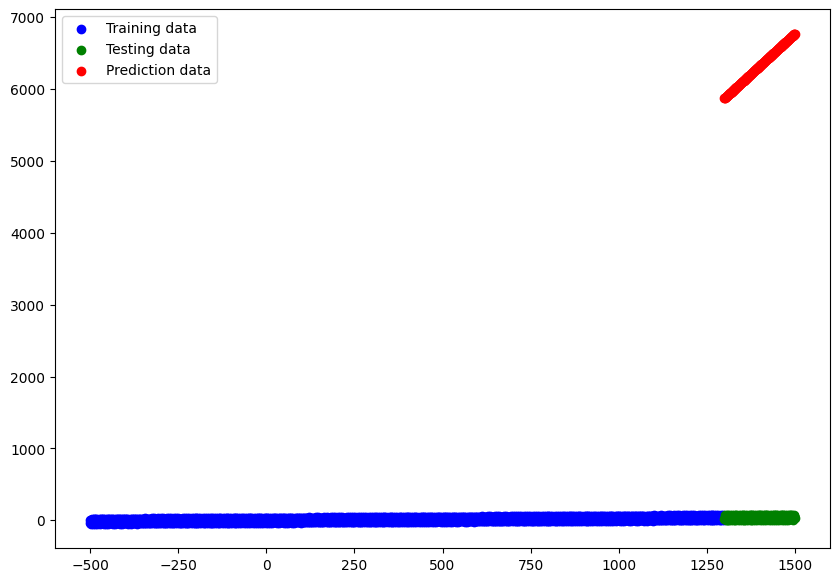

```python
plot_predictions(X_train, y_train, X_test, y_test, y_preds1)
```

Hmmm it seems to be very inaccurate. Sure it did predict that as `X` increases, then y should increase as well. But it's taken that factor out of proportion, and estimated y values over 6000! Let's see what we can do to our model to further improve accuracy.

### Normalization

We'll try normalize our values to between 0 and 1, as this is a common way to preprocess our data, and is easier for the machine learning model to digest the training data. We'll use `MinMaxScaler`.

```python
# normalize our data with MinMaxScaler from sklearn
from sklearn.preprocessing import MinMaxScaler

scaler = MinMaxScaler(feature_range=(0,1)) # state that our min max results are between 0 and 1, effectively normalizing it
y_scaled = scaler.fit_transform(tf.expand_dims(y, axis=-1)) # fit our scaler function onto y, and expand y from 1D to 2D array to not cause error
y_scaled
```

```
array([[0.40383578],
       [0.1396778 ],
       [0.        ],
       ...,
       [1.        ],
       [0.86630795],
       [0.60233511]])
```

```python
y_scaled_train = y_scaled[:1800] # new scaled train dataset
y_scaled_test = y_scaled[1800:] # new scaled test dataset
```

let's copy and paste down the visualized data graph and see if its sucessfully normalized

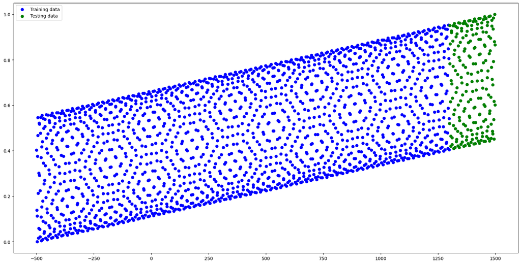

```python
# visualize the separate data of training and test in a graph
plt.figure(figsize=(20,10))
# plot training data in blue
plt.scatter(X_train, y_scaled_train, c='b', label='Training data')
# plot test data in green
plt.scatter(X_test, y_scaled_test, c='g', label='Testing data')
# Show the legend
plt.legend();
```

let's try training and testing `model1` with this preprocessed data, to see if our adjustments have made an improvement on the results.

```python
model1.fit(tf.expand_dims(X_train, axis=-1), y_scaled_train, epochs=100)
```

```
---------------------------------------------------------------------------
ValueError                                Traceback (most recent call last)
Cell In[327], line 1
----> 1 model1.fit(tf.expand_dims(X_train, axis=-1), y_scaled_train, epochs=100)

File c:\Users\capma\AppData\Local\Programs\Python\Python39\lib\site-packages\keras\src\utils\traceback_utils.py:122, in filter_traceback.<locals>.error_handler(*args, **kwargs)
    119     filtered_tb = _process_traceback_frames(e.__traceback__)
    120     # To get the full stack trace, call:
    121     # `keras.config.disable_traceback_filtering()`
--> 122     raise e.with_traceback(filtered_tb) from None
    123 finally:
    124     del filtered_tb

File c:\Users\capma\AppData\Local\Programs\Python\Python39\lib\site-packages\optree\ops.py:752, in tree_map(func, tree, is_leaf, none_is_leaf, namespace, *rests)
    750 leaves, treespec = _C.flatten(tree, is_leaf, none_is_leaf, namespace)
    751 flat_args = [leaves] + [treespec.flatten_up_to(r) for r in rests]
--> 752 return treespec.unflatten(map(func, *flat_args))

ValueError: Cannot take the length of shape with unknown rank.
```

there seems to something wrong with the shape. We know that X_train had no issues with fitting on model, but might have to do with y_scaled_train. let's have a look at the shape

```python
print(y_scaled_train.shape), print(X_train.shape)
```

```
(1800, 1)
(1800,)
```

```
(None, None)
```

```python
y_scaled_train[:5]
```

```
array([[0.40383578],
       [0.1396778 ],
       [0.        ],
       [0.11342847],
       [0.37588455]])
```

It could be because we are in a 2d array for `y_scaled`, but is normally 1d array for `y`. We'll have to flaten it using `tf.squeeze()`.

```python
y_scaled = tf.squeeze(y_scaled)
y_scaled.shape
```

```
TensorShape([2000])
```

```python
y_scaled_train = y_scaled[:1800]
y_scaled_test = y_scaled[1800:]

model1.fit(tf.expand_dims(X_train, axis=-1), y_scaled_train, epochs=100)
```

```
57/57 ━━━━━━━━━━━━━━━━━━━━ 1s 7ms/step - loss: 1372.9656 - mae: 1372.9656
57/57 ━━━━━━━━━━━━━━━━━━━━ 1s 6ms/step - loss: 1472.3014 - mae: 1472.3014
57/57 ━━━━━━━━━━━━━━━━━━━━ 1s 3ms/step - loss: 1475.8826 - mae: 1475.8826
57/57 ━━━━━━━━━━━━━━━━━━━━ 0s 3ms/step - loss: 1479.4897 - mae: 1479.4897
57/57 ━━━━━━━━━━━━━━━━━━━━ 0s 2ms/step - loss: 1478.4037 - mae: 1478.4037
57/57 ━━━━━━━━━━━━━━━━━━━━ 0s 3ms/step - loss: 1479.4899 - mae: 1479.4899
57/57 ━━━━━━━━━━━━━━━━━━━━ 0s 3ms/step - loss: 1478.4034 - mae: 1478.4034
57/57 ━━━━━━━━━━━━━━━━━━━━ 0s 2ms/step - loss: 1479.4897 - mae: 1479.4897
57/57 ━━━━━━━━━━━━━━━━━━━━ 0s 2ms/step - loss: 1478.4036 - mae: 1478.4036
57/57 ━━━━━━━━━━━━━━━━━━━━ 0s 3ms/step - loss: 1479.4897 - mae: 1479.4897
57/57 ━━━━━━━━━━━━━━━━━━━━ 0s 2ms/step - loss: 1478.4036 - mae: 1478.4036
57/57 ━━━━━━━━━━━━━━━━━━━━ 0s 2ms/step - loss: 1479.4897 - mae: 1479.4897
57/57 ━━━━━━━━━━━━━━━━━━━━ 0s 2ms/step - loss: 1478.4036 - mae: 1478.4036
57/57 ━━━━━━━━━━━━━━━━━━━━ 0s 3ms/step - loss: 1479.4900 - mae: 1479.4900
57/57 ━━━━━━━━━━━━━━━━━━━━ 0s 2ms/step - loss: 1478.4036 - mae: 1478.4036
57/57 ━━━━━━━━━━━━━━━━━━━━ 0s 2ms/step - loss: 1479.4899 - mae: 1479.4899
57/57 ━━━━━━━━━━━━━━━━━━━━ 0s 2ms/step - loss: 1478.4037 - mae: 1478.4037
57/57 ━━━━━━━━━━━━━━━━━━━━ 0s 3ms/step - loss: 1479.4899 - mae: 1479.4899
57/57 ━━━━━━━━━━━━━━━━━━━━ 0s 2ms/step - loss: 1478.4036 - mae: 1478.4036
57/57 ━━━━━━━━━━━━━━━━━━━━ 0s 2ms/step - loss: 1479.4900 - mae: 1479.4900
57/57 ━━━━━━━━━━━━━━━━━━━━ 0s 2ms/step - loss: 1478.4037 - mae: 1478.4037
57/57 ━━━━━━━━━━━━━━━━━━━━ 0s 2ms/step - loss: 1479.4899 - mae: 1479.4899
57/57 ━━━━━━━━━━━━━━━━━━━━ 0s 2ms/step - loss: 1478.4037 - mae: 1478.4037
57/57 ━━━━━━━━━━━━━━━━━━━━ 0s 2ms/step - loss: 1479.4900 - mae: 1479.4900
57/57 ━━━━━━━━━━━━━━━━━━━━ 0s 2ms/step - loss: 1478.4037 - mae: 1478.4037
57/57 ━━━━━━━━━━━━━━━━━━━━ 0s 3ms/step - loss: 1479.4899 - mae: 1479.4899
57/57 ━━━━━━━━━━━━━━━━━━━━ 0s 2ms/step - loss: 1478.4037 - mae: 1478.4037
57/57 ━━━━━━━━━━━━━━━━━━━━ 0s 3ms/step - loss: 1479.4899 - mae: 1479.4899
57/57 ━━━━━━━━━━━━━━━━━━━━ 0s 2ms/step - loss: 1478.4034 - mae: 1478.4034
57/57 ━━━━━━━━━━━━━━━━━━━━ 0s 2ms/step - loss: 1479.4899 - mae: 1479.4899
57/57 ━━━━━━━━━━━━━━━━━━━━ 0s 3ms/step - loss: 1478.4034 - mae: 1478.4034
57/57 ━━━━━━━━━━━━━━━━━━━━ 0s 2ms/step - loss: 1479.4900 - mae: 1479.4900
57/57 ━━━━━━━━━━━━━━━━━━━━ 0s 2ms/step - loss: 1478.4037 - mae: 1478.4037
57/57 ━━━━━━━━━━━━━━━━━━━━ 0s 2ms/step - loss: 1479.4901 - mae: 1479.4901
57/57 ━━━━━━━━━━━━━━━━━━━━ 0s 2ms/step - loss: 1478.4036 - mae: 1478.4036
57/57 ━━━━━━━━━━━━━━━━━━━━ 0s 2ms/step - loss: 1479.4900 - mae: 1479.4900
57/57 ━━━━━━━━━━━━━━━━━━━━ 0s 2ms/step - loss: 1478.4034 - mae: 1478.4034
57/57 ━━━━━━━━━━━━━━━━━━━━ 0s 2ms/step - loss: 1479.4899 - mae: 1479.4899
57/57 ━━━━━━━━━━━━━━━━━━━━ 0s 2ms/step - loss: 1478.4036 - mae: 1478.4036
57/57 ━━━━━━━━━━━━━━━━━━━━ 0s 2ms/step - loss: 1479.4899 - mae: 1479.4899
```

[output cut: 45 more lines]

```
57/57 ━━━━━━━━━━━━━━━━━━━━ 0s 3ms/step - loss: 1479.4899 - mae: 1479.4899
57/57 ━━━━━━━━━━━━━━━━━━━━ 0s 5ms/step - loss: 1478.4036 - mae: 1478.4036
57/57 ━━━━━━━━━━━━━━━━━━━━ 0s 2ms/step - loss: 1479.4899 - mae: 1479.4899
57/57 ━━━━━━━━━━━━━━━━━━━━ 0s 3ms/step - loss: 1478.4037 - mae: 1478.4037
57/57 ━━━━━━━━━━━━━━━━━━━━ 0s 2ms/step - loss: 1479.4899 - mae: 1479.4899
57/57 ━━━━━━━━━━━━━━━━━━━━ 0s 2ms/step - loss: 1478.4036 - mae: 1478.4036
57/57 ━━━━━━━━━━━━━━━━━━━━ 0s 2ms/step - loss: 1479.4900 - mae: 1479.4900
57/57 ━━━━━━━━━━━━━━━━━━━━ 0s 2ms/step - loss: 1478.4034 - mae: 1478.4034
57/57 ━━━━━━━━━━━━━━━━━━━━ 0s 2ms/step - loss: 1479.4899 - mae: 1479.4899
57/57 ━━━━━━━━━━━━━━━━━━━━ 0s 2ms/step - loss: 1478.4036 - mae: 1478.4036
57/57 ━━━━━━━━━━━━━━━━━━━━ 0s 2ms/step - loss: 1479.4899 - mae: 1479.4899
57/57 ━━━━━━━━━━━━━━━━━━━━ 0s 2ms/step - loss: 1478.4036 - mae: 1478.4036
57/57 ━━━━━━━━━━━━━━━━━━━━ 0s 2ms/step - loss: 1479.4896 - mae: 1479.4896
57/57 ━━━━━━━━━━━━━━━━━━━━ 0s 2ms/step - loss: 1478.4034 - mae: 1478.4034
57/57 ━━━━━━━━━━━━━━━━━━━━ 0s 3ms/step - loss: 1479.4897 - mae: 1479.4897
```

```
<keras.src.callbacks.history.History at 0x267058875b0>
```

The normalization doesn't seem to improve on the model's accuracy. Let's see what other ways we can try improve on model accuracy.

I looked at a image exemplar on the list of things one could do to hopefully improve the model's accuracy. One caught my eye on the `optimizer`, where you use `Adam` and set the brackets within with the value of `0.0001`. Let's see if it does anything.

> **Note**: `0.0001` is the `learning rate` for `Adam`. So what is this so called learning rate? It determines the sizes of the steps Adam will take when searching optimal parameters. Too high values will cause predictions to over shoot and fail to converge to on an answer, while too low trains too slow and becomes too cautious.

```python
# Set seet
tf.random.set_seed(35)

# create model, with 4 layers
model = tf.keras.Sequential([
    tf.keras.layers.Dense(1)
])

# compile the model
model.compile(loss=tf.keras.losses.mae,
              optimizer=tf.keras.optimizers.Adam(0.0001),
              metrics=['mae'])

# fit model
model.fit(tf.expand_dims(X_train, axis=-1), y_scaled_train, epochs=100)
```

```
57/57 ━━━━━━━━━━━━━━━━━━━━ 3s 3ms/step - loss: 359.1370 - mae: 359.1370
57/57 ━━━━━━━━━━━━━━━━━━━━ 0s 2ms/step - loss: 356.0981 - mae: 356.0981
57/57 ━━━━━━━━━━━━━━━━━━━━ 0s 2ms/step - loss: 353.0737 - mae: 353.0737
57/57 ━━━━━━━━━━━━━━━━━━━━ 0s 2ms/step - loss: 350.0544 - mae: 350.0544
57/57 ━━━━━━━━━━━━━━━━━━━━ 0s 2ms/step - loss: 347.0374 - mae: 347.0374
57/57 ━━━━━━━━━━━━━━━━━━━━ 0s 2ms/step - loss: 344.0215 - mae: 344.0215
57/57 ━━━━━━━━━━━━━━━━━━━━ 0s 2ms/step - loss: 341.0068 - mae: 341.0068
57/57 ━━━━━━━━━━━━━━━━━━━━ 0s 2ms/step - loss: 337.9925 - mae: 337.9925
57/57 ━━━━━━━━━━━━━━━━━━━━ 0s 2ms/step - loss: 334.9786 - mae: 334.9786
57/57 ━━━━━━━━━━━━━━━━━━━━ 0s 2ms/step - loss: 331.9651 - mae: 331.9651
57/57 ━━━━━━━━━━━━━━━━━━━━ 0s 2ms/step - loss: 328.9519 - mae: 328.9519
57/57 ━━━━━━━━━━━━━━━━━━━━ 0s 2ms/step - loss: 325.9390 - mae: 325.9390
57/57 ━━━━━━━━━━━━━━━━━━━━ 0s 3ms/step - loss: 322.9261 - mae: 322.9261
57/57 ━━━━━━━━━━━━━━━━━━━━ 0s 2ms/step - loss: 319.9133 - mae: 319.9133
57/57 ━━━━━━━━━━━━━━━━━━━━ 0s 2ms/step - loss: 316.9007 - mae: 316.9007
57/57 ━━━━━━━━━━━━━━━━━━━━ 0s 3ms/step - loss: 313.8882 - mae: 313.8882
57/57 ━━━━━━━━━━━━━━━━━━━━ 0s 2ms/step - loss: 310.8759 - mae: 310.8759
57/57 ━━━━━━━━━━━━━━━━━━━━ 0s 2ms/step - loss: 307.8636 - mae: 307.8636
57/57 ━━━━━━━━━━━━━━━━━━━━ 0s 2ms/step - loss: 304.8515 - mae: 304.8515
57/57 ━━━━━━━━━━━━━━━━━━━━ 0s 2ms/step - loss: 301.8393 - mae: 301.8393
57/57 ━━━━━━━━━━━━━━━━━━━━ 0s 2ms/step - loss: 298.8271 - mae: 298.8271
57/57 ━━━━━━━━━━━━━━━━━━━━ 0s 3ms/step - loss: 295.8151 - mae: 295.8151
57/57 ━━━━━━━━━━━━━━━━━━━━ 0s 2ms/step - loss: 292.8031 - mae: 292.8031
57/57 ━━━━━━━━━━━━━━━━━━━━ 0s 2ms/step - loss: 289.7911 - mae: 289.7911
57/57 ━━━━━━━━━━━━━━━━━━━━ 0s 2ms/step - loss: 286.7791 - mae: 286.7791
57/57 ━━━━━━━━━━━━━━━━━━━━ 0s 2ms/step - loss: 283.7672 - mae: 283.7672
57/57 ━━━━━━━━━━━━━━━━━━━━ 0s 2ms/step - loss: 280.7553 - mae: 280.7553
57/57 ━━━━━━━━━━━━━━━━━━━━ 0s 2ms/step - loss: 277.7435 - mae: 277.7435
57/57 ━━━━━━━━━━━━━━━━━━━━ 0s 2ms/step - loss: 274.7316 - mae: 274.7316
57/57 ━━━━━━━━━━━━━━━━━━━━ 0s 2ms/step - loss: 271.7198 - mae: 271.7198
57/57 ━━━━━━━━━━━━━━━━━━━━ 0s 2ms/step - loss: 268.7081 - mae: 268.7081
57/57 ━━━━━━━━━━━━━━━━━━━━ 0s 2ms/step - loss: 265.6964 - mae: 265.6964
57/57 ━━━━━━━━━━━━━━━━━━━━ 0s 3ms/step - loss: 262.6846 - mae: 262.6846
57/57 ━━━━━━━━━━━━━━━━━━━━ 0s 3ms/step - loss: 259.6729 - mae: 259.6729
57/57 ━━━━━━━━━━━━━━━━━━━━ 0s 3ms/step - loss: 256.6613 - mae: 256.6613
57/57 ━━━━━━━━━━━━━━━━━━━━ 0s 2ms/step - loss: 253.6496 - mae: 253.6496
57/57 ━━━━━━━━━━━━━━━━━━━━ 0s 2ms/step - loss: 250.6380 - mae: 250.6380
57/57 ━━━━━━━━━━━━━━━━━━━━ 0s 3ms/step - loss: 247.6263 - mae: 247.6263
57/57 ━━━━━━━━━━━━━━━━━━━━ 0s 2ms/step - loss: 244.6147 - mae: 244.6147
57/57 ━━━━━━━━━━━━━━━━━━━━ 0s 2ms/step - loss: 241.6031 - mae: 241.6031
```

[output cut: 45 more lines]

```
57/57 ━━━━━━━━━━━━━━━━━━━━ 0s 2ms/step - loss: 103.0748 - mae: 103.0748
57/57 ━━━━━━━━━━━━━━━━━━━━ 0s 3ms/step - loss: 100.0633 - mae: 100.0633
57/57 ━━━━━━━━━━━━━━━━━━━━ 0s 4ms/step - loss: 97.0519 - mae: 97.0519
57/57 ━━━━━━━━━━━━━━━━━━━━ 0s 4ms/step - loss: 94.0405 - mae: 94.0405
57/57 ━━━━━━━━━━━━━━━━━━━━ 0s 2ms/step - loss: 91.0290 - mae: 91.0290
57/57 ━━━━━━━━━━━━━━━━━━━━ 0s 2ms/step - loss: 88.0176 - mae: 88.0176
57/57 ━━━━━━━━━━━━━━━━━━━━ 0s 2ms/step - loss: 85.0062 - mae: 85.0062
57/57 ━━━━━━━━━━━━━━━━━━━━ 0s 2ms/step - loss: 81.9950 - mae: 81.9950
57/57 ━━━━━━━━━━━━━━━━━━━━ 0s 2ms/step - loss: 78.9837 - mae: 78.9837
57/57 ━━━━━━━━━━━━━━━━━━━━ 0s 2ms/step - loss: 75.9725 - mae: 75.9725
57/57 ━━━━━━━━━━━━━━━━━━━━ 0s 2ms/step - loss: 72.9613 - mae: 72.9613
57/57 ━━━━━━━━━━━━━━━━━━━━ 0s 2ms/step - loss: 69.9502 - mae: 69.9502
57/57 ━━━━━━━━━━━━━━━━━━━━ 0s 2ms/step - loss: 66.9391 - mae: 66.9391
57/57 ━━━━━━━━━━━━━━━━━━━━ 0s 2ms/step - loss: 63.9280 - mae: 63.9280
57/57 ━━━━━━━━━━━━━━━━━━━━ 0s 2ms/step - loss: 60.9170 - mae: 60.9170
```

```
<keras.src.callbacks.history.History at 0x267065ffc40>
```

Seems like our shot in the dark has proved fruitful! The given results are a million times better than before :)

Let's check the results through our test data and visualize in graph.

```python
model2 = model
y_preds2 = model2.predict(X_test)

y_preds2
```

```
7/7 ━━━━━━━━━━━━━━━━━━━━ 2s 147ms/step
```

```
array([[144.28183],
       [144.39322],
       [144.50461],
       [144.61601],
       [144.7274 ],
       [144.83879],
       [144.9502 ],
       [145.06158],
       [145.17297],
       [145.28438],
       [145.39577],
       [145.50716],
       [145.61856],
       [145.72995],
       [145.84134],
       [145.95274],
       [146.06413],
       [146.17552],
       [146.28693],
       [146.39832],
       [146.5097 ],
       [146.62111],
       [146.7325 ],
       [146.84389],
       [146.95528],
       [147.06668],
       [147.17807],
       [147.28946],
       [147.40086],
       [147.51225],
       [147.62364],
       [147.73505],
       [147.84644],
       [147.95782],
       [148.06923],
       [148.18062],
       [148.292  ],
       [148.40341],
       [148.5148 ],
       [148.62619],
```

[output cut: 145 more lines]

```
       [164.88974],
       [165.00113],
       [165.11253],
       [165.22392],
       [165.33531],
       [165.44672],
       [165.5581 ],
       [165.6695 ],
       [165.7809 ],
       [165.89229],
       [166.00368],
       [166.11508],
       [166.22647],
       [166.33786],
       [166.44926]], dtype=float32)
```

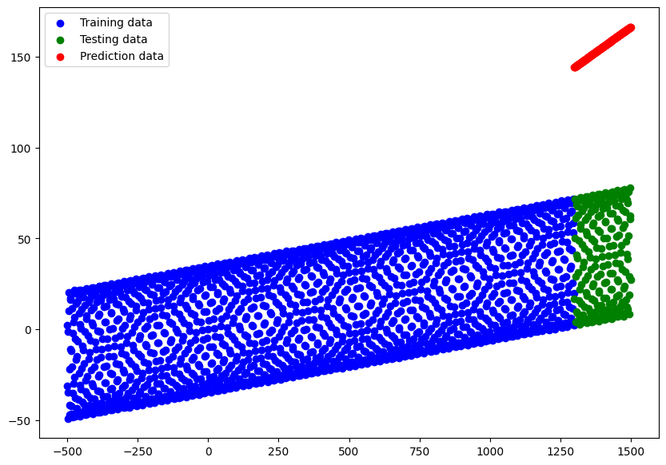

```python
plot_predictions(X_train, y_train, X_test, y_test, y_preds2)
```

Still a ways away from the true answer, but getting there! Let's see if normalizing will help as well.

#### Model 2

```python
# model predicting on normalized y
model2.fit(tf.expand_dims(X_train, axis=-1), y_scaled_train, epochs=100)
# predicting on test data
y_scaled_preds2 = model2.predict(X_test)
# plot our predictions
plot_predictions(X_train, y_scaled_train, X_test, y_scaled_test, y_scaled_preds2)
```

[output not shown]

```
57/57 ━━━━━━━━━━━━━━━━━━━━ 1s 9ms/step - loss: 57.9060 - mae: 57.9060
57/57 ━━━━━━━━━━━━━━━━━━━━ 0s 4ms/step - loss: 54.8951 - mae: 54.8951
57/57 ━━━━━━━━━━━━━━━━━━━━ 0s 2ms/step - loss: 51.8841 - mae: 51.8841
57/57 ━━━━━━━━━━━━━━━━━━━━ 0s 5ms/step - loss: 48.8732 - mae: 48.8732
57/57 ━━━━━━━━━━━━━━━━━━━━ 0s 3ms/step - loss: 45.8622 - mae: 45.8622
57/57 ━━━━━━━━━━━━━━━━━━━━ 0s 5ms/step - loss: 42.8516 - mae: 42.8516
57/57 ━━━━━━━━━━━━━━━━━━━━ 0s 3ms/step - loss: 39.8414 - mae: 39.8414
57/57 ━━━━━━━━━━━━━━━━━━━━ 0s 3ms/step - loss: 36.8315 - mae: 36.8315
57/57 ━━━━━━━━━━━━━━━━━━━━ 0s 2ms/step - loss: 33.8217 - mae: 33.8217
57/57 ━━━━━━━━━━━━━━━━━━━━ 0s 2ms/step - loss: 30.8121 - mae: 30.8121
57/57 ━━━━━━━━━━━━━━━━━━━━ 0s 3ms/step - loss: 27.8028 - mae: 27.8028
57/57 ━━━━━━━━━━━━━━━━━━━━ 0s 3ms/step - loss: 24.7938 - mae: 24.7938
57/57 ━━━━━━━━━━━━━━━━━━━━ 0s 5ms/step - loss: 21.7853 - mae: 21.7853
57/57 ━━━━━━━━━━━━━━━━━━━━ 0s 4ms/step - loss: 18.7775 - mae: 18.7775
57/57 ━━━━━━━━━━━━━━━━━━━━ 0s 3ms/step - loss: 15.7713 - mae: 15.7713
57/57 ━━━━━━━━━━━━━━━━━━━━ 0s 3ms/step - loss: 12.7680 - mae: 12.7680
57/57 ━━━━━━━━━━━━━━━━━━━━ 0s 3ms/step - loss: 9.7696 - mae: 9.7696
57/57 ━━━━━━━━━━━━━━━━━━━━ 0s 2ms/step - loss: 6.7806 - mae: 6.7806
57/57 ━━━━━━━━━━━━━━━━━━━━ 0s 2ms/step - loss: 3.8263 - mae: 3.8263
57/57 ━━━━━━━━━━━━━━━━━━━━ 0s 3ms/step - loss: 1.2072 - mae: 1.2072
57/57 ━━━━━━━━━━━━━━━━━━━━ 0s 3ms/step - loss: 0.6793 - mae: 0.6793
57/57 ━━━━━━━━━━━━━━━━━━━━ 0s 3ms/step - loss: 0.6740 - mae: 0.6740
57/57 ━━━━━━━━━━━━━━━━━━━━ 0s 2ms/step - loss: 0.6691 - mae: 0.6691
57/57 ━━━━━━━━━━━━━━━━━━━━ 0s 2ms/step - loss: 0.6644 - mae: 0.6644
57/57 ━━━━━━━━━━━━━━━━━━━━ 0s 2ms/step - loss: 0.6597 - mae: 0.6597
57/57 ━━━━━━━━━━━━━━━━━━━━ 0s 3ms/step - loss: 0.6553 - mae: 0.6553
57/57 ━━━━━━━━━━━━━━━━━━━━ 0s 2ms/step - loss: 0.6509 - mae: 0.6509
57/57 ━━━━━━━━━━━━━━━━━━━━ 0s 2ms/step - loss: 0.6466 - mae: 0.6466
57/57 ━━━━━━━━━━━━━━━━━━━━ 0s 2ms/step - loss: 0.6423 - mae: 0.6423
57/57 ━━━━━━━━━━━━━━━━━━━━ 0s 2ms/step - loss: 0.6381 - mae: 0.6381
57/57 ━━━━━━━━━━━━━━━━━━━━ 0s 3ms/step - loss: 0.6340 - mae: 0.6340
57/57 ━━━━━━━━━━━━━━━━━━━━ 0s 2ms/step - loss: 0.6299 - mae: 0.6299
57/57 ━━━━━━━━━━━━━━━━━━━━ 0s 2ms/step - loss: 0.6259 - mae: 0.6259
57/57 ━━━━━━━━━━━━━━━━━━━━ 0s 3ms/step - loss: 0.6221 - mae: 0.6221
57/57 ━━━━━━━━━━━━━━━━━━━━ 0s 2ms/step - loss: 0.6181 - mae: 0.6181
57/57 ━━━━━━━━━━━━━━━━━━━━ 0s 2ms/step - loss: 0.6142 - mae: 0.6142
57/57 ━━━━━━━━━━━━━━━━━━━━ 0s 2ms/step - loss: 0.6103 - mae: 0.6103
57/57 ━━━━━━━━━━━━━━━━━━━━ 0s 2ms/step - loss: 0.6064 - mae: 0.6064
57/57 ━━━━━━━━━━━━━━━━━━━━ 0s 3ms/step - loss: 0.6026 - mae: 0.6026
57/57 ━━━━━━━━━━━━━━━━━━━━ 0s 3ms/step - loss: 0.5986 - mae: 0.5986
```

[output cut: 46 more lines]

```
57/57 ━━━━━━━━━━━━━━━━━━━━ 0s 2ms/step - loss: 0.4334 - mae: 0.4334
57/57 ━━━━━━━━━━━━━━━━━━━━ 0s 2ms/step - loss: 0.4300 - mae: 0.4300
57/57 ━━━━━━━━━━━━━━━━━━━━ 1s 9ms/step - loss: 0.4265 - mae: 0.4265
57/57 ━━━━━━━━━━━━━━━━━━━━ 0s 3ms/step - loss: 0.4241 - mae: 0.4241
57/57 ━━━━━━━━━━━━━━━━━━━━ 0s 2ms/step - loss: 0.4202 - mae: 0.4202
57/57 ━━━━━━━━━━━━━━━━━━━━ 0s 3ms/step - loss: 0.4172 - mae: 0.4172
57/57 ━━━━━━━━━━━━━━━━━━━━ 0s 2ms/step - loss: 0.4133 - mae: 0.4133
57/57 ━━━━━━━━━━━━━━━━━━━━ 0s 3ms/step - loss: 0.4106 - mae: 0.4106
57/57 ━━━━━━━━━━━━━━━━━━━━ 0s 2ms/step - loss: 0.4067 - mae: 0.4067
57/57 ━━━━━━━━━━━━━━━━━━━━ 0s 3ms/step - loss: 0.4039 - mae: 0.4039
57/57 ━━━━━━━━━━━━━━━━━━━━ 0s 3ms/step - loss: 0.4001 - mae: 0.4001
57/57 ━━━━━━━━━━━━━━━━━━━━ 0s 2ms/step - loss: 0.3975 - mae: 0.3975
57/57 ━━━━━━━━━━━━━━━━━━━━ 0s 2ms/step - loss: 0.3936 - mae: 0.3936
57/57 ━━━━━━━━━━━━━━━━━━━━ 0s 3ms/step - loss: 0.3906 - mae: 0.3906
7/7 ━━━━━━━━━━━━━━━━━━━━ 0s 4ms/step
```

This time normalization has brought it even closer! But biggest problem of all, it's been displaying this straight line prediction! Not sure why this happens, but we'll try and figure it out with the help of ChatGPT!

**1. Insufficient model complexity**

> Notice how we only have one layer in our `Sequential` portion of the dataset. ChatGPT suggests that our model is too simple and doesn't allow enough complexity for it to discover the actual patterns. Because it only has one neuron, the most it can do is basically predict linear patterns!

**2. Activation function issues**

> If our layers only contain activation functions that only seeks simple linear patterns, then it'll definitely not be able to find out the non-linear patterns of this data! So we have to ensure that we're using nonlinear activations.

**3. Normalizing X**

> Sometimes, normalizing just one result may not help the ML model, and you'll have to do it for both X and y data sets.

**4. Loss function choice**

> The main two we see is `MSE (Mean Squared Error)`, and `MAE (Mean Absolute Error)`. And we currently have MAE in use in our model. ChatGPT suggests that MSE works better on normalized data compared to MAE.

**5. Learning rate too high**

> Our Adam function might be overshooting the optimal solution, and may need to decrease the learning rate.

**6. Insufficient training/Overfitted on linear components**

> The model might have not trained long enough to find the pattern, and also may need to require an `early stopping` function, to prevent mode from over fitting too much.

Given the list of possible things to debug, we will go down the list one by one, and see how it affects the results when compared to `model2`, which we'll treat as our baseline.

#### 1. Insufficient Model Complexity

```python
# Set seet
tf.random.set_seed(35)

# create model, with 4 layers
model = tf.keras.Sequential([
    tf.keras.layers.Dense(64),
    tf.keras.layers.Dense(1)
])

# compile the model
model.compile(loss=tf.keras.losses.mae,
              optimizer=tf.keras.optimizers.Adam(0.0001),
              metrics=['mae'])

# fit model
model.fit(tf.expand_dims(X_train, axis=-1), y_scaled_train, epochs=100)
```

```
57/57 ━━━━━━━━━━━━━━━━━━━━ 4s 3ms/step - loss: 36.7993 - mae: 36.7993
57/57 ━━━━━━━━━━━━━━━━━━━━ 0s 3ms/step - loss: 1.2710 - mae: 1.2710
57/57 ━━━━━━━━━━━━━━━━━━━━ 0s 3ms/step - loss: 0.2505 - mae: 0.2505
57/57 ━━━━━━━━━━━━━━━━━━━━ 0s 3ms/step - loss: 0.2283 - mae: 0.2283
57/57 ━━━━━━━━━━━━━━━━━━━━ 0s 3ms/step - loss: 0.2153 - mae: 0.2153
57/57 ━━━━━━━━━━━━━━━━━━━━ 0s 4ms/step - loss: 0.2053 - mae: 0.2053
57/57 ━━━━━━━━━━━━━━━━━━━━ 0s 3ms/step - loss: 0.1957 - mae: 0.1957
57/57 ━━━━━━━━━━━━━━━━━━━━ 0s 3ms/step - loss: 0.1939 - mae: 0.1939
57/57 ━━━━━━━━━━━━━━━━━━━━ 0s 3ms/step - loss: 0.1931 - mae: 0.1931
57/57 ━━━━━━━━━━━━━━━━━━━━ 0s 3ms/step - loss: 0.1980 - mae: 0.1980
57/57 ━━━━━━━━━━━━━━━━━━━━ 0s 3ms/step - loss: 0.1892 - mae: 0.1892
57/57 ━━━━━━━━━━━━━━━━━━━━ 0s 3ms/step - loss: 0.1927 - mae: 0.1927
57/57 ━━━━━━━━━━━━━━━━━━━━ 0s 4ms/step - loss: 0.1971 - mae: 0.1971
57/57 ━━━━━━━━━━━━━━━━━━━━ 0s 4ms/step - loss: 0.1912 - mae: 0.1912
57/57 ━━━━━━━━━━━━━━━━━━━━ 0s 4ms/step - loss: 0.1950 - mae: 0.1950
57/57 ━━━━━━━━━━━━━━━━━━━━ 0s 3ms/step - loss: 0.2107 - mae: 0.2107
57/57 ━━━━━━━━━━━━━━━━━━━━ 0s 3ms/step - loss: 0.2076 - mae: 0.2076
57/57 ━━━━━━━━━━━━━━━━━━━━ 0s 3ms/step - loss: 0.1989 - mae: 0.1989
57/57 ━━━━━━━━━━━━━━━━━━━━ 0s 4ms/step - loss: 0.2067 - mae: 0.2067
57/57 ━━━━━━━━━━━━━━━━━━━━ 0s 4ms/step - loss: 0.2234 - mae: 0.2234
57/57 ━━━━━━━━━━━━━━━━━━━━ 0s 5ms/step - loss: 0.1956 - mae: 0.1956
57/57 ━━━━━━━━━━━━━━━━━━━━ 0s 3ms/step - loss: 0.1933 - mae: 0.1933
57/57 ━━━━━━━━━━━━━━━━━━━━ 0s 4ms/step - loss: 0.2012 - mae: 0.2012
57/57 ━━━━━━━━━━━━━━━━━━━━ 0s 3ms/step - loss: 0.1933 - mae: 0.1933
57/57 ━━━━━━━━━━━━━━━━━━━━ 0s 3ms/step - loss: 0.1911 - mae: 0.1911
57/57 ━━━━━━━━━━━━━━━━━━━━ 0s 3ms/step - loss: 0.1933 - mae: 0.1933
57/57 ━━━━━━━━━━━━━━━━━━━━ 0s 4ms/step - loss: 0.1953 - mae: 0.1953
57/57 ━━━━━━━━━━━━━━━━━━━━ 0s 4ms/step - loss: 0.1942 - mae: 0.1942
57/57 ━━━━━━━━━━━━━━━━━━━━ 0s 4ms/step - loss: 0.2051 - mae: 0.2051
57/57 ━━━━━━━━━━━━━━━━━━━━ 0s 3ms/step - loss: 0.1962 - mae: 0.1962
57/57 ━━━━━━━━━━━━━━━━━━━━ 0s 3ms/step - loss: 0.2011 - mae: 0.2011
57/57 ━━━━━━━━━━━━━━━━━━━━ 0s 5ms/step - loss: 0.2020 - mae: 0.2020
57/57 ━━━━━━━━━━━━━━━━━━━━ 0s 3ms/step - loss: 0.1957 - mae: 0.1957
57/57 ━━━━━━━━━━━━━━━━━━━━ 0s 2ms/step - loss: 0.1913 - mae: 0.1913
57/57 ━━━━━━━━━━━━━━━━━━━━ 0s 2ms/step - loss: 0.1967 - mae: 0.1967
57/57 ━━━━━━━━━━━━━━━━━━━━ 0s 2ms/step - loss: 0.2019 - mae: 0.2019
57/57 ━━━━━━━━━━━━━━━━━━━━ 0s 2ms/step - loss: 0.1950 - mae: 0.1950
57/57 ━━━━━━━━━━━━━━━━━━━━ 0s 3ms/step - loss: 0.2189 - mae: 0.2189
57/57 ━━━━━━━━━━━━━━━━━━━━ 0s 2ms/step - loss: 0.1904 - mae: 0.1904
57/57 ━━━━━━━━━━━━━━━━━━━━ 0s 4ms/step - loss: 0.1931 - mae: 0.1931
```

[output cut: 45 more lines]

```
57/57 ━━━━━━━━━━━━━━━━━━━━ 0s 3ms/step - loss: 0.1898 - mae: 0.1898
57/57 ━━━━━━━━━━━━━━━━━━━━ 0s 2ms/step - loss: 0.1959 - mae: 0.1959
57/57 ━━━━━━━━━━━━━━━━━━━━ 0s 2ms/step - loss: 0.1958 - mae: 0.1958
57/57 ━━━━━━━━━━━━━━━━━━━━ 0s 3ms/step - loss: 0.1943 - mae: 0.1943
57/57 ━━━━━━━━━━━━━━━━━━━━ 0s 3ms/step - loss: 0.2045 - mae: 0.2045
57/57 ━━━━━━━━━━━━━━━━━━━━ 0s 3ms/step - loss: 0.1954 - mae: 0.1954
57/57 ━━━━━━━━━━━━━━━━━━━━ 0s 4ms/step - loss: 0.2053 - mae: 0.2053
57/57 ━━━━━━━━━━━━━━━━━━━━ 0s 3ms/step - loss: 0.1941 - mae: 0.1941
57/57 ━━━━━━━━━━━━━━━━━━━━ 0s 3ms/step - loss: 0.1983 - mae: 0.1983
57/57 ━━━━━━━━━━━━━━━━━━━━ 0s 3ms/step - loss: 0.1988 - mae: 0.1988
57/57 ━━━━━━━━━━━━━━━━━━━━ 0s 3ms/step - loss: 0.2007 - mae: 0.2007
57/57 ━━━━━━━━━━━━━━━━━━━━ 0s 3ms/step - loss: 0.1989 - mae: 0.1989
57/57 ━━━━━━━━━━━━━━━━━━━━ 0s 3ms/step - loss: 0.1919 - mae: 0.1919
57/57 ━━━━━━━━━━━━━━━━━━━━ 0s 3ms/step - loss: 0.1946 - mae: 0.1946
57/57 ━━━━━━━━━━━━━━━━━━━━ 0s 4ms/step - loss: 0.2305 - mae: 0.2305
```

```
<keras.src.callbacks.history.History at 0x267096f9820>
```

#### Model 3

```
7/7 ━━━━━━━━━━━━━━━━━━━━ 0s 16ms/step
```

```
(None, None)
```

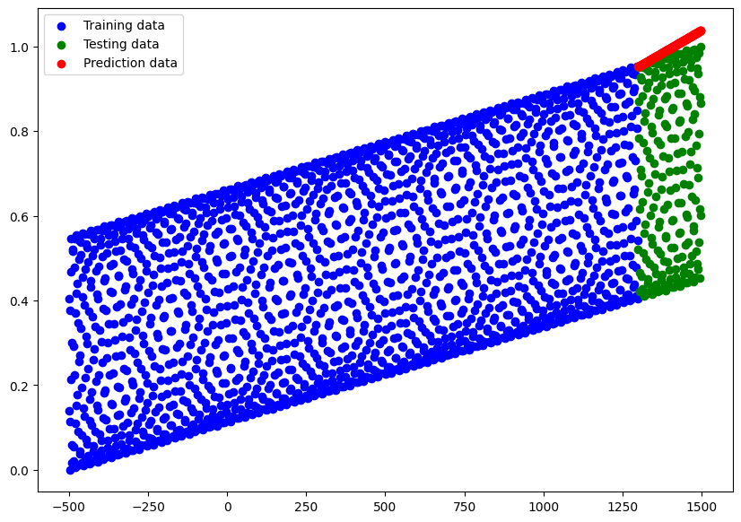

```python
y_scaled_preds3 = model.predict(X_test)

plot_predictions(X_train, y_scaled_train, X_test, y_scaled_test, y_scaled_preds3), plot_predictions(X_train, y_scaled_train, X_test, y_scaled_test, y_scaled_preds2)
```

Adding complexity to the model has helped increase accuracy, but has not fixed our largest issue, linearity in predictions. We've also seem to have fixed our previous issue with `Nan` results on our `mae`.

#### 2. Activation function issues

I've asked ChatGPT a list of nonlinear activation function that i can implement into the model, and here are the list that it has provided:

**1. Rectified Linear Unit (ReLU)**: Most often used for deep learning, effecient and mitigates vanishing gradient problems.

**2. Leaky ReLU**: Solves dying ReLU (where neuron outputs zero for every input) by allowing small negative gradients

**3. Parametrics ReLU (PReLU)**: Adds flexibility to Leaky ReLU, by learning slopes of the negative region

**4. Exponential Linear Unit (ELU)**: Used to improve convergence and mitigate vanishing gradients

**5. Swish**: Outperforms ReLU on deeper networks

**6. Sigmoid**: Common for output layers in binary classifications

**7. Tanh (Hyperbolic Tangent)**: Often used in hidden layers for data centered at zero

**8. Softmax**: Output layer for multi-class classification

**9. GELU (Gaussian Error Linear Unit)**: Popular in transformer models (e.g. BERT)

**10. Softplus**: Nonliner alternative to ReLU

**11. Maxout**: Provides learnable piecewise linearity, often outperforming ReLU

**12. Sinusoidal Activation**: Rarely used but suitable for periodic data or in Fourier-related models

**Glossary because there are terms I don't understand**:

> Vanishing gradient: *Where gradients become very small, and prevents networks from learning effectively. If it happens early, then layers further down don't work.*

> Negative gradient: *Weights have increased too much, causing dead neurons, and reduces the amount of learning.*

> Negative region: *Outputs negative values, helps network with modelling more diverse relationships.*

> Improve convergence: *Makes model learn faster*

> Hidden layers: *Layers between the input and output layers, processing and extracting features from data.*

> Transformer Models: *Neural Network Architecture designed to handle sequential data, e.g. natural laguage processing.*

> Piecewise linearity: *Functions compoased of multiple linear segments, allows approximation on nonlinear relationships.*

> Fourier-related models: *Model leveraging fourier transforms, useful for modelling periodic or oscillatory patterns in data (e.g. sine waves).*

#### What should we try?

**Parametrics ReLU**: ReLU is common used for deep learning, thinking parametrics would be good. Theorized the flexibility would help with the complexity of data

**Exponential Linear Unit**: Want to utilize improvement on convergence, and minimize vanishing gradient

**Softplus**: Utilize non linearity of model, as it fits the data I've formulated

**Maxout**: Utilize its non linear finding relationships, and its outperformance of ReLU

**Sinusoidal Activation**: Suited for periodic/oscillatory patterns. Perfect for the sine wave in the data

#### ChatGPT consultation

I wasn't sure how to implement those layers into our sequential layer model, so I decided to ask ChatGPT for such code. Though it did return quite a bit of code for `Maxout`. I want to try and understand the code that ChatGPT has outputted, but figure to leave `Maxout` for next time, as there's a lot of things I'm not sure how to interpret.

```
# Custom Maxout Layer
class Maxout(tf.keras.layers.Layer):
    def __init__(self, num_units, num_pieces):
        super(Maxout, self).__init__()
        self.num_units = num_units
        self.num_pieces = num_pieces

    def build(self, input_shape):
        self.weights = self.add_weight(
            shape=(input_shape[-1], self.num_units * self.num_pieces),
            initializer="glorot_uniform",
            trainable=True,
        )
        self.biases = self.add_weight(
            shape=(self.num_units * self.num_pieces,),
            initializer="zeros",
            trainable=True,
        )

    def call(self, inputs):
        z = tf.matmul(inputs, self.weights) + self.biases
        z = tf.reshape(z, [-1, self.num_units, self.num_pieces])
        return tf.reduce_max(z, axis=-1)
```

I decided to add all those different activation function, since it'll take a while to go through all of them, and was curious how all these work together.

```python
from tensorflow.keras.layers import Dense, PReLU, ELU, Activation, Lambda

# Set seed
tf.random.set_seed(35)

# Custom Sinusoidal Activation Function
def sinusoidal(x):
    return tf.sin(x) # takes x, and applies sine to said x. Meant to introduce periodic behaviour into the model's actions, aka sine waves.

# Create the model
model = tf.keras.Sequential([
    tf.keras.layers.Dense(128),  # Input Layer of 128 neurons
    # 1. PReLU Activation
    PReLU(),

    # 2. ELU Activation
    Dense(128),  # Fully connected layer to the previous layer of 128 neurons
    ELU(alpha=1.0),

    # 3. Softplus Activation
    Dense(128),
    Activation('softplus'),

    # 4. Sinusoidal Activation
    Dense(128),
    Lambda(sinusoidal), # applying Siusoidal activation using Lambda. Lanbda allows the use of arbitrary functions as an activation. In our example, it applies the sine function to the output of the dense layer.

    # Output Layer
    Dense(1)
])

# Compile the model
model.compile(
    loss=tf.keras.losses.mae,
    optimizer=tf.keras.optimizers.Adam(learning_rate=0.0001),
    metrics=['mae']
)

# Fit the model
model.fit(tf.expand_dims(X_train, axis=-1), y_scaled_train, epochs=100)
```

```
WARNING:tensorflow:From c:\Users\capma\AppData\Local\Programs\Python\Python39\lib\site-packages\keras\src\backend\tensorflow\core.py:222: The name tf.placeholder is deprecated. Please use tf.compat.v1.placeholder instead.
```

[output not shown]

```
57/57 ━━━━━━━━━━━━━━━━━━━━ 21s 21ms/step - loss: 0.6986 - mae: 0.6986
57/57 ━━━━━━━━━━━━━━━━━━━━ 0s 5ms/step - loss: 0.4801 - mae: 0.4801
57/57 ━━━━━━━━━━━━━━━━━━━━ 0s 3ms/step - loss: 0.5120 - mae: 0.5120
57/57 ━━━━━━━━━━━━━━━━━━━━ 0s 4ms/step - loss: 0.4626 - mae: 0.4626
57/57 ━━━━━━━━━━━━━━━━━━━━ 0s 4ms/step - loss: 0.4071 - mae: 0.4071
57/57 ━━━━━━━━━━━━━━━━━━━━ 0s 5ms/step - loss: 0.4131 - mae: 0.4131
57/57 ━━━━━━━━━━━━━━━━━━━━ 0s 3ms/step - loss: 0.4763 - mae: 0.4763
57/57 ━━━━━━━━━━━━━━━━━━━━ 0s 3ms/step - loss: 0.4268 - mae: 0.4268
57/57 ━━━━━━━━━━━━━━━━━━━━ 0s 3ms/step - loss: 0.4109 - mae: 0.4109
57/57 ━━━━━━━━━━━━━━━━━━━━ 0s 3ms/step - loss: 0.3942 - mae: 0.3942
57/57 ━━━━━━━━━━━━━━━━━━━━ 0s 3ms/step - loss: 0.4207 - mae: 0.4207
57/57 ━━━━━━━━━━━━━━━━━━━━ 0s 3ms/step - loss: 0.4128 - mae: 0.4128
57/57 ━━━━━━━━━━━━━━━━━━━━ 0s 3ms/step - loss: 0.4367 - mae: 0.4367
57/57 ━━━━━━━━━━━━━━━━━━━━ 0s 3ms/step - loss: 0.3595 - mae: 0.3595
57/57 ━━━━━━━━━━━━━━━━━━━━ 0s 3ms/step - loss: 0.3977 - mae: 0.3977
57/57 ━━━━━━━━━━━━━━━━━━━━ 0s 5ms/step - loss: 0.3887 - mae: 0.3887
57/57 ━━━━━━━━━━━━━━━━━━━━ 0s 3ms/step - loss: 0.3751 - mae: 0.3751
57/57 ━━━━━━━━━━━━━━━━━━━━ 0s 3ms/step - loss: 0.3813 - mae: 0.3813
57/57 ━━━━━━━━━━━━━━━━━━━━ 0s 3ms/step - loss: 0.3992 - mae: 0.3992
57/57 ━━━━━━━━━━━━━━━━━━━━ 0s 3ms/step - loss: 0.4389 - mae: 0.4389
57/57 ━━━━━━━━━━━━━━━━━━━━ 0s 3ms/step - loss: 0.4540 - mae: 0.4540
57/57 ━━━━━━━━━━━━━━━━━━━━ 0s 3ms/step - loss: 0.3928 - mae: 0.3928
57/57 ━━━━━━━━━━━━━━━━━━━━ 0s 4ms/step - loss: 0.4118 - mae: 0.4118
57/57 ━━━━━━━━━━━━━━━━━━━━ 0s 5ms/step - loss: 0.3715 - mae: 0.3715
57/57 ━━━━━━━━━━━━━━━━━━━━ 0s 3ms/step - loss: 0.4138 - mae: 0.4138
57/57 ━━━━━━━━━━━━━━━━━━━━ 0s 4ms/step - loss: 0.3752 - mae: 0.3752
57/57 ━━━━━━━━━━━━━━━━━━━━ 0s 3ms/step - loss: 0.3943 - mae: 0.3943
57/57 ━━━━━━━━━━━━━━━━━━━━ 0s 3ms/step - loss: 0.3381 - mae: 0.3381
57/57 ━━━━━━━━━━━━━━━━━━━━ 0s 3ms/step - loss: 0.3420 - mae: 0.3420
57/57 ━━━━━━━━━━━━━━━━━━━━ 0s 3ms/step - loss: 0.3380 - mae: 0.3380
57/57 ━━━━━━━━━━━━━━━━━━━━ 0s 4ms/step - loss: 0.3207 - mae: 0.3207
57/57 ━━━━━━━━━━━━━━━━━━━━ 0s 3ms/step - loss: 0.3624 - mae: 0.3624
57/57 ━━━━━━━━━━━━━━━━━━━━ 0s 3ms/step - loss: 0.3560 - mae: 0.3560
57/57 ━━━━━━━━━━━━━━━━━━━━ 0s 3ms/step - loss: 0.3734 - mae: 0.3734
57/57 ━━━━━━━━━━━━━━━━━━━━ 0s 3ms/step - loss: 0.3272 - mae: 0.3272
57/57 ━━━━━━━━━━━━━━━━━━━━ 0s 4ms/step - loss: 0.3238 - mae: 0.3238
57/57 ━━━━━━━━━━━━━━━━━━━━ 0s 5ms/step - loss: 0.3779 - mae: 0.3779
57/57 ━━━━━━━━━━━━━━━━━━━━ 0s 5ms/step - loss: 0.3719 - mae: 0.3719
57/57 ━━━━━━━━━━━━━━━━━━━━ 0s 3ms/step - loss: 0.3526 - mae: 0.3526
57/57 ━━━━━━━━━━━━━━━━━━━━ 0s 3ms/step - loss: 0.3486 - mae: 0.3486
```

[output cut: 45 more lines]

```
57/57 ━━━━━━━━━━━━━━━━━━━━ 0s 4ms/step - loss: 0.2574 - mae: 0.2574
57/57 ━━━━━━━━━━━━━━━━━━━━ 0s 3ms/step - loss: 0.2786 - mae: 0.2786
57/57 ━━━━━━━━━━━━━━━━━━━━ 0s 3ms/step - loss: 0.2561 - mae: 0.2561
57/57 ━━━━━━━━━━━━━━━━━━━━ 0s 3ms/step - loss: 0.2853 - mae: 0.2853
57/57 ━━━━━━━━━━━━━━━━━━━━ 0s 3ms/step - loss: 0.2624 - mae: 0.2624
57/57 ━━━━━━━━━━━━━━━━━━━━ 0s 3ms/step - loss: 0.2361 - mae: 0.2361
57/57 ━━━━━━━━━━━━━━━━━━━━ 0s 3ms/step - loss: 0.2650 - mae: 0.2650
57/57 ━━━━━━━━━━━━━━━━━━━━ 0s 3ms/step - loss: 0.2599 - mae: 0.2599
57/57 ━━━━━━━━━━━━━━━━━━━━ 0s 3ms/step - loss: 0.2437 - mae: 0.2437
57/57 ━━━━━━━━━━━━━━━━━━━━ 0s 3ms/step - loss: 0.2415 - mae: 0.2415
57/57 ━━━━━━━━━━━━━━━━━━━━ 0s 3ms/step - loss: 0.2526 - mae: 0.2526
57/57 ━━━━━━━━━━━━━━━━━━━━ 0s 3ms/step - loss: 0.2725 - mae: 0.2725
57/57 ━━━━━━━━━━━━━━━━━━━━ 0s 3ms/step - loss: 0.2357 - mae: 0.2357
57/57 ━━━━━━━━━━━━━━━━━━━━ 0s 3ms/step - loss: 0.2526 - mae: 0.2526
57/57 ━━━━━━━━━━━━━━━━━━━━ 0s 4ms/step - loss: 0.2449 - mae: 0.2449
```

```
<keras.src.callbacks.history.History at 0x267098fd0a0>
```

#### Model 4

```
7/7 ━━━━━━━━━━━━━━━━━━━━ 1s 37ms/step
```

```
(None, None)
```

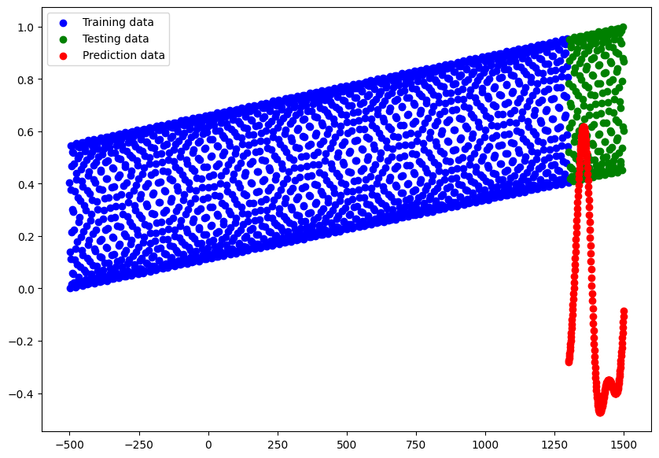

```python
y_scaled_preds4 = model.predict(X_test)

plot_predictions(X_train, y_scaled_train, X_test, y_scaled_test, y_scaled_preds4), plot_predictions(X_train, y_scaled_train, X_test, y_scaled_test, y_scaled_preds2)
```

We've fixed the issue of linear results in the data, which is a good step. But it has picked negative values, which our y-values don't have. We can figure that out through our list of activation functions.

#### 3. Normalize X

like y, let's normalize x and see what it does.

```python
X_scaled = scaler.fit_transform(tf.expand_dims(X, axis=-1)) # fit our scaler function onto y, and expand y from 1D to 2D array to not cause error
X_scaled

X_scaled_train = X_scaled[:1800]
X_scaled_test = X_scaled[1800:]
```

```python
tf.random.set_seed(35)

model = tf.keras.Sequential([
    tf.keras.layers.Dense(1)
])

# compile the model
model.compile(loss=tf.keras.losses.mae,
              optimizer=tf.keras.optimizers.Adam(0.0001),
              metrics=['mae'])

# fit model
model.fit(tf.expand_dims(X_scaled_train, axis=-1), y_scaled_train, epochs=100)
```

```
57/57 ━━━━━━━━━━━━━━━━━━━━ 2s 4ms/step - loss: 0.2695 - mae: 0.2695
57/57 ━━━━━━━━━━━━━━━━━━━━ 0s 4ms/step - loss: 0.2671 - mae: 0.2671
57/57 ━━━━━━━━━━━━━━━━━━━━ 0s 3ms/step - loss: 0.2649 - mae: 0.2649
57/57 ━━━━━━━━━━━━━━━━━━━━ 0s 2ms/step - loss: 0.2629 - mae: 0.2629
57/57 ━━━━━━━━━━━━━━━━━━━━ 0s 2ms/step - loss: 0.2611 - mae: 0.2611
57/57 ━━━━━━━━━━━━━━━━━━━━ 0s 2ms/step - loss: 0.2594 - mae: 0.2594
57/57 ━━━━━━━━━━━━━━━━━━━━ 0s 2ms/step - loss: 0.2579 - mae: 0.2579
57/57 ━━━━━━━━━━━━━━━━━━━━ 0s 3ms/step - loss: 0.2565 - mae: 0.2565
57/57 ━━━━━━━━━━━━━━━━━━━━ 0s 3ms/step - loss: 0.2551 - mae: 0.2551
57/57 ━━━━━━━━━━━━━━━━━━━━ 0s 3ms/step - loss: 0.2539 - mae: 0.2539
57/57 ━━━━━━━━━━━━━━━━━━━━ 0s 2ms/step - loss: 0.2527 - mae: 0.2527
57/57 ━━━━━━━━━━━━━━━━━━━━ 0s 2ms/step - loss: 0.2516 - mae: 0.2516
57/57 ━━━━━━━━━━━━━━━━━━━━ 0s 2ms/step - loss: 0.2506 - mae: 0.2506
57/57 ━━━━━━━━━━━━━━━━━━━━ 0s 2ms/step - loss: 0.2496 - mae: 0.2496
57/57 ━━━━━━━━━━━━━━━━━━━━ 0s 2ms/step - loss: 0.2487 - mae: 0.2487
57/57 ━━━━━━━━━━━━━━━━━━━━ 0s 2ms/step - loss: 0.2478 - mae: 0.2478
57/57 ━━━━━━━━━━━━━━━━━━━━ 0s 2ms/step - loss: 0.2469 - mae: 0.2469
57/57 ━━━━━━━━━━━━━━━━━━━━ 0s 3ms/step - loss: 0.2460 - mae: 0.2460
57/57 ━━━━━━━━━━━━━━━━━━━━ 0s 2ms/step - loss: 0.2452 - mae: 0.2452
57/57 ━━━━━━━━━━━━━━━━━━━━ 0s 2ms/step - loss: 0.2444 - mae: 0.2444
57/57 ━━━━━━━━━━━━━━━━━━━━ 0s 2ms/step - loss: 0.2436 - mae: 0.2436
57/57 ━━━━━━━━━━━━━━━━━━━━ 0s 3ms/step - loss: 0.2428 - mae: 0.2428
57/57 ━━━━━━━━━━━━━━━━━━━━ 0s 2ms/step - loss: 0.2420 - mae: 0.2420
57/57 ━━━━━━━━━━━━━━━━━━━━ 0s 2ms/step - loss: 0.2412 - mae: 0.2412
57/57 ━━━━━━━━━━━━━━━━━━━━ 0s 2ms/step - loss: 0.2405 - mae: 0.2405
57/57 ━━━━━━━━━━━━━━━━━━━━ 0s 5ms/step - loss: 0.2397 - mae: 0.2397
57/57 ━━━━━━━━━━━━━━━━━━━━ 0s 3ms/step - loss: 0.2390 - mae: 0.2390
57/57 ━━━━━━━━━━━━━━━━━━━━ 0s 3ms/step - loss: 0.2383 - mae: 0.2383
57/57 ━━━━━━━━━━━━━━━━━━━━ 0s 3ms/step - loss: 0.2376 - mae: 0.2376
57/57 ━━━━━━━━━━━━━━━━━━━━ 0s 3ms/step - loss: 0.2369 - mae: 0.2369
57/57 ━━━━━━━━━━━━━━━━━━━━ 0s 3ms/step - loss: 0.2362 - mae: 0.2362
57/57 ━━━━━━━━━━━━━━━━━━━━ 0s 3ms/step - loss: 0.2356 - mae: 0.2356
57/57 ━━━━━━━━━━━━━━━━━━━━ 0s 2ms/step - loss: 0.2349 - mae: 0.2349
57/57 ━━━━━━━━━━━━━━━━━━━━ 0s 2ms/step - loss: 0.2342 - mae: 0.2342
57/57 ━━━━━━━━━━━━━━━━━━━━ 0s 3ms/step - loss: 0.2336 - mae: 0.2336
57/57 ━━━━━━━━━━━━━━━━━━━━ 0s 3ms/step - loss: 0.2329 - mae: 0.2329
57/57 ━━━━━━━━━━━━━━━━━━━━ 0s 2ms/step - loss: 0.2323 - mae: 0.2323
57/57 ━━━━━━━━━━━━━━━━━━━━ 0s 3ms/step - loss: 0.2317 - mae: 0.2317
57/57 ━━━━━━━━━━━━━━━━━━━━ 0s 3ms/step - loss: 0.2311 - mae: 0.2311
57/57 ━━━━━━━━━━━━━━━━━━━━ 0s 3ms/step - loss: 0.2305 - mae: 0.2305
```

[output cut: 45 more lines]

```
57/57 ━━━━━━━━━━━━━━━━━━━━ 0s 3ms/step - loss: 0.2110 - mae: 0.2110
57/57 ━━━━━━━━━━━━━━━━━━━━ 0s 3ms/step - loss: 0.2107 - mae: 0.2107
57/57 ━━━━━━━━━━━━━━━━━━━━ 0s 2ms/step - loss: 0.2104 - mae: 0.2104
57/57 ━━━━━━━━━━━━━━━━━━━━ 0s 3ms/step - loss: 0.2101 - mae: 0.2101
57/57 ━━━━━━━━━━━━━━━━━━━━ 0s 4ms/step - loss: 0.2099 - mae: 0.2099
57/57 ━━━━━━━━━━━━━━━━━━━━ 0s 3ms/step - loss: 0.2096 - mae: 0.2096
57/57 ━━━━━━━━━━━━━━━━━━━━ 0s 4ms/step - loss: 0.2093 - mae: 0.2093
57/57 ━━━━━━━━━━━━━━━━━━━━ 0s 3ms/step - loss: 0.2091 - mae: 0.2091
57/57 ━━━━━━━━━━━━━━━━━━━━ 0s 2ms/step - loss: 0.2088 - mae: 0.2088
57/57 ━━━━━━━━━━━━━━━━━━━━ 0s 2ms/step - loss: 0.2086 - mae: 0.2086
57/57 ━━━━━━━━━━━━━━━━━━━━ 0s 2ms/step - loss: 0.2083 - mae: 0.2083
57/57 ━━━━━━━━━━━━━━━━━━━━ 0s 3ms/step - loss: 0.2081 - mae: 0.2081
57/57 ━━━━━━━━━━━━━━━━━━━━ 0s 3ms/step - loss: 0.2079 - mae: 0.2079
57/57 ━━━━━━━━━━━━━━━━━━━━ 0s 3ms/step - loss: 0.2076 - mae: 0.2076
57/57 ━━━━━━━━━━━━━━━━━━━━ 0s 3ms/step - loss: 0.2074 - mae: 0.2074
```

```
<keras.src.callbacks.history.History at 0x26709815700>
```

#### Model 5

```
7/7 ━━━━━━━━━━━━━━━━━━━━ 0s 11ms/step
```

```
(None, None)
```

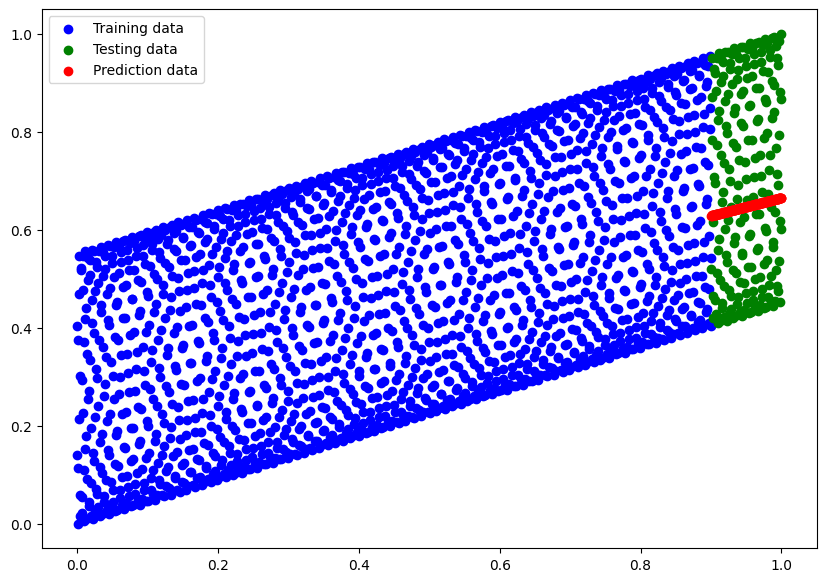

```python
y_scaled_preds5 = model.predict(X_scaled_test)

plot_predictions(X_scaled_train, y_scaled_train, X_scaled_test, y_scaled_test, y_scaled_preds5), plot_predictions(X_train, y_scaled_train, X_test, y_scaled_test, y_scaled_preds2)
```

The predictions is even better! Despite it being a linear prediction, it's lining up quite close to the mean of the values.

#### 4. Loss Function Choice

```python
tf.random.set_seed(35)

model = tf.keras.Sequential([
    tf.keras.layers.Dense(1)
])

# compile the model
model.compile(loss=tf.keras.losses.mae,
              optimizer=tf.keras.optimizers.Adam(0.0001),
              metrics=['mse'])

# fit model
model.fit(tf.expand_dims(X_train, axis=-1), y_scaled_train, epochs=100)
```

```
57/57 ━━━━━━━━━━━━━━━━━━━━ 1s 2ms/step - loss: 822.0550 - mse: 1015611.4375
57/57 ━━━━━━━━━━━━━━━━━━━━ 0s 2ms/step - loss: 819.0159 - mse: 1008115.5625
57/57 ━━━━━━━━━━━━━━━━━━━━ 0s 2ms/step - loss: 815.9914 - mse: 1000682.9375
57/57 ━━━━━━━━━━━━━━━━━━━━ 0s 2ms/step - loss: 812.9722 - mse: 993291.1250
57/57 ━━━━━━━━━━━━━━━━━━━━ 0s 2ms/step - loss: 809.9550 - mse: 985931.3125
57/57 ━━━━━━━━━━━━━━━━━━━━ 0s 2ms/step - loss: 806.9395 - mse: 978602.9375
57/57 ━━━━━━━━━━━━━━━━━━━━ 0s 2ms/step - loss: 803.9246 - mse: 971303.6250
57/57 ━━━━━━━━━━━━━━━━━━━━ 0s 3ms/step - loss: 800.9103 - mse: 964032.9375
57/57 ━━━━━━━━━━━━━━━━━━━━ 0s 2ms/step - loss: 797.8965 - mse: 956790.5000
57/57 ━━━━━━━━━━━━━━━━━━━━ 0s 2ms/step - loss: 794.8830 - mse: 949576.3125
57/57 ━━━━━━━━━━━━━━━━━━━━ 0s 2ms/step - loss: 791.8698 - mse: 942390.2500
57/57 ━━━━━━━━━━━━━━━━━━━━ 0s 2ms/step - loss: 788.8569 - mse: 935232.0000
57/57 ━━━━━━━━━━━━━━━━━━━━ 0s 2ms/step - loss: 785.8443 - mse: 928102.0000
57/57 ━━━━━━━━━━━━━━━━━━━━ 0s 2ms/step - loss: 782.8317 - mse: 920999.0000
57/57 ━━━━━━━━━━━━━━━━━━━━ 0s 2ms/step - loss: 779.8192 - mse: 913923.6875
57/57 ━━━━━━━━━━━━━━━━━━━━ 0s 3ms/step - loss: 776.8069 - mse: 906876.0625
57/57 ━━━━━━━━━━━━━━━━━━━━ 0s 2ms/step - loss: 773.7946 - mse: 899855.5625
57/57 ━━━━━━━━━━━━━━━━━━━━ 0s 2ms/step - loss: 770.7823 - mse: 892862.7500
57/57 ━━━━━━━━━━━━━━━━━━━━ 0s 2ms/step - loss: 767.7702 - mse: 885897.4375
57/57 ━━━━━━━━━━━━━━━━━━━━ 0s 2ms/step - loss: 764.7581 - mse: 878959.5000
57/57 ━━━━━━━━━━━━━━━━━━━━ 0s 2ms/step - loss: 761.7460 - mse: 872048.7500
57/57 ━━━━━━━━━━━━━━━━━━━━ 0s 2ms/step - loss: 758.7339 - mse: 865165.1875
57/57 ━━━━━━━━━━━━━━━━━━━━ 0s 2ms/step - loss: 755.7219 - mse: 858309.0625
57/57 ━━━━━━━━━━━━━━━━━━━━ 0s 2ms/step - loss: 752.7098 - mse: 851480.3750
57/57 ━━━━━━━━━━━━━━━━━━━━ 0s 2ms/step - loss: 749.6979 - mse: 844679.0000
57/57 ━━━━━━━━━━━━━━━━━━━━ 0s 4ms/step - loss: 746.6859 - mse: 837904.9375
57/57 ━━━━━━━━━━━━━━━━━━━━ 0s 3ms/step - loss: 743.6740 - mse: 831158.2500
57/57 ━━━━━━━━━━━━━━━━━━━━ 0s 2ms/step - loss: 740.6622 - mse: 824439.0625
57/57 ━━━━━━━━━━━━━━━━━━━━ 0s 2ms/step - loss: 737.6503 - mse: 817747.0625
57/57 ━━━━━━━━━━━━━━━━━━━━ 0s 2ms/step - loss: 734.6385 - mse: 811082.3750
57/57 ━━━━━━━━━━━━━━━━━━━━ 0s 2ms/step - loss: 731.6267 - mse: 804444.8750
57/57 ━━━━━━━━━━━━━━━━━━━━ 0s 2ms/step - loss: 728.6149 - mse: 797834.7500
57/57 ━━━━━━━━━━━━━━━━━━━━ 0s 2ms/step - loss: 725.6031 - mse: 791252.0625
57/57 ━━━━━━━━━━━━━━━━━━━━ 0s 2ms/step - loss: 722.5914 - mse: 784696.5000
57/57 ━━━━━━━━━━━━━━━━━━━━ 0s 2ms/step - loss: 719.5795 - mse: 778168.3750
57/57 ━━━━━━━━━━━━━━━━━━━━ 0s 2ms/step - loss: 716.5678 - mse: 771667.5625
57/57 ━━━━━━━━━━━━━━━━━━━━ 0s 2ms/step - loss: 713.5562 - mse: 765194.0000
57/57 ━━━━━━━━━━━━━━━━━━━━ 0s 2ms/step - loss: 710.5445 - mse: 758747.7500
57/57 ━━━━━━━━━━━━━━━━━━━━ 0s 2ms/step - loss: 707.5327 - mse: 752328.6875
57/57 ━━━━━━━━━━━━━━━━━━━━ 0s 2ms/step - loss: 704.5209 - mse: 745937.0000
```

[output cut: 45 more lines]

```
57/57 ━━━━━━━━━━━━━━━━━━━━ 0s 2ms/step - loss: 565.9897 - mse: 481405.5625
57/57 ━━━━━━━━━━━━━━━━━━━━ 0s 2ms/step - loss: 562.9781 - mse: 476295.6562
57/57 ━━━━━━━━━━━━━━━━━━━━ 0s 2ms/step - loss: 559.9667 - mse: 471213.0938
57/57 ━━━━━━━━━━━━━━━━━━━━ 0s 2ms/step - loss: 556.9551 - mse: 466157.6562
57/57 ━━━━━━━━━━━━━━━━━━━━ 0s 3ms/step - loss: 553.9437 - mse: 461129.5938
57/57 ━━━━━━━━━━━━━━━━━━━━ 0s 2ms/step - loss: 550.9321 - mse: 456128.8125
57/57 ━━━━━━━━━━━━━━━━━━━━ 0s 2ms/step - loss: 547.9207 - mse: 451155.1875
57/57 ━━━━━━━━━━━━━━━━━━━━ 0s 2ms/step - loss: 544.9091 - mse: 446208.9375
57/57 ━━━━━━━━━━━━━━━━━━━━ 0s 2ms/step - loss: 541.8976 - mse: 441289.9375
57/57 ━━━━━━━━━━━━━━━━━━━━ 0s 2ms/step - loss: 538.8861 - mse: 436398.1562
57/57 ━━━━━━━━━━━━━━━━━━━━ 0s 2ms/step - loss: 535.8745 - mse: 431533.6250
57/57 ━━━━━━━━━━━━━━━━━━━━ 0s 2ms/step - loss: 532.8630 - mse: 426696.3750
57/57 ━━━━━━━━━━━━━━━━━━━━ 0s 2ms/step - loss: 529.8517 - mse: 421886.4688
57/57 ━━━━━━━━━━━━━━━━━━━━ 0s 2ms/step - loss: 526.8401 - mse: 417103.6875
57/57 ━━━━━━━━━━━━━━━━━━━━ 0s 2ms/step - loss: 523.8286 - mse: 412348.1875
```

```
<keras.src.callbacks.history.History at 0x267136ebf40>
```

#### Model 6

```
7/7 ━━━━━━━━━━━━━━━━━━━━ 0s 8ms/step
```

```
(None, None)
```

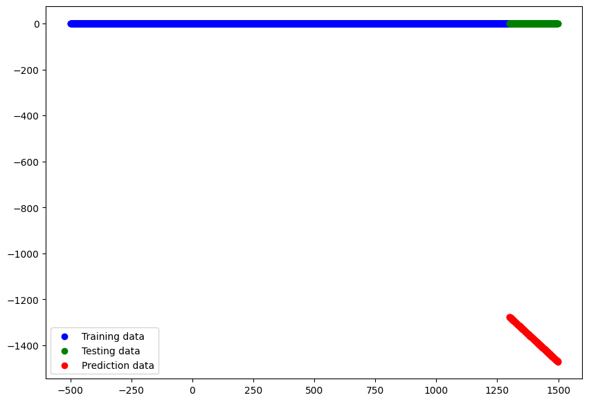

```python
y_scaled_preds6 = model.predict(X_test)

plot_predictions(X_train, y_scaled_train, X_test, y_scaled_test, y_scaled_preds6), plot_predictions(X_train, y_scaled_train, X_test, y_scaled_test, y_scaled_preds2)
```

#### 5. Learning rate too high

```python
tf.random.set_seed(35)

model = tf.keras.Sequential([
    tf.keras.layers.Dense(1)
])

# compile the model
model.compile(loss=tf.keras.losses.mae,
              optimizer=tf.keras.optimizers.Adam(0.001),
              metrics=['mae'])

# fit model
model.fit(tf.expand_dims(X_train, axis=-1), y_scaled_train, epochs=100)
```

```
57/57 ━━━━━━━━━━━━━━━━━━━━ 1s 2ms/step - loss: 177.9045 - mae: 177.9045
57/57 ━━━━━━━━━━━━━━━━━━━━ 0s 2ms/step - loss: 147.5139 - mae: 147.5139
57/57 ━━━━━━━━━━━━━━━━━━━━ 0s 2ms/step - loss: 117.2692 - mae: 117.2692
57/57 ━━━━━━━━━━━━━━━━━━━━ 0s 2ms/step - loss: 87.0759 - mae: 87.0759
57/57 ━━━━━━━━━━━━━━━━━━━━ 0s 2ms/step - loss: 56.9055 - mae: 56.9055
57/57 ━━━━━━━━━━━━━━━━━━━━ 0s 2ms/step - loss: 26.7487 - mae: 26.7487
57/57 ━━━━━━━━━━━━━━━━━━━━ 0s 2ms/step - loss: 1.5380 - mae: 1.5380
57/57 ━━━━━━━━━━━━━━━━━━━━ 0s 2ms/step - loss: 0.1874 - mae: 0.1874
57/57 ━━━━━━━━━━━━━━━━━━━━ 0s 2ms/step - loss: 0.1810 - mae: 0.1810
57/57 ━━━━━━━━━━━━━━━━━━━━ 0s 3ms/step - loss: 0.1806 - mae: 0.1806
57/57 ━━━━━━━━━━━━━━━━━━━━ 0s 2ms/step - loss: 0.1871 - mae: 0.1871
57/57 ━━━━━━━━━━━━━━━━━━━━ 0s 2ms/step - loss: 0.1913 - mae: 0.1913
57/57 ━━━━━━━━━━━━━━━━━━━━ 0s 2ms/step - loss: 0.1845 - mae: 0.1845
57/57 ━━━━━━━━━━━━━━━━━━━━ 0s 2ms/step - loss: 0.1961 - mae: 0.1961
57/57 ━━━━━━━━━━━━━━━━━━━━ 0s 2ms/step - loss: 0.1881 - mae: 0.1881
57/57 ━━━━━━━━━━━━━━━━━━━━ 0s 2ms/step - loss: 0.1897 - mae: 0.1897
57/57 ━━━━━━━━━━━━━━━━━━━━ 0s 2ms/step - loss: 0.1871 - mae: 0.1871
57/57 ━━━━━━━━━━━━━━━━━━━━ 0s 2ms/step - loss: 0.1867 - mae: 0.1867
57/57 ━━━━━━━━━━━━━━━━━━━━ 0s 2ms/step - loss: 0.1863 - mae: 0.1863
57/57 ━━━━━━━━━━━━━━━━━━━━ 0s 2ms/step - loss: 0.1875 - mae: 0.1875
57/57 ━━━━━━━━━━━━━━━━━━━━ 0s 2ms/step - loss: 0.1869 - mae: 0.1869
57/57 ━━━━━━━━━━━━━━━━━━━━ 0s 2ms/step - loss: 0.1873 - mae: 0.1873
57/57 ━━━━━━━━━━━━━━━━━━━━ 0s 2ms/step - loss: 0.1925 - mae: 0.1925
57/57 ━━━━━━━━━━━━━━━━━━━━ 0s 2ms/step - loss: 0.1869 - mae: 0.1869
57/57 ━━━━━━━━━━━━━━━━━━━━ 0s 2ms/step - loss: 0.1851 - mae: 0.1851
57/57 ━━━━━━━━━━━━━━━━━━━━ 0s 2ms/step - loss: 0.1860 - mae: 0.1860
57/57 ━━━━━━━━━━━━━━━━━━━━ 0s 2ms/step - loss: 0.1890 - mae: 0.1890
57/57 ━━━━━━━━━━━━━━━━━━━━ 0s 2ms/step - loss: 0.1936 - mae: 0.1936
57/57 ━━━━━━━━━━━━━━━━━━━━ 0s 2ms/step - loss: 0.1868 - mae: 0.1868
57/57 ━━━━━━━━━━━━━━━━━━━━ 0s 2ms/step - loss: 0.1854 - mae: 0.1854
57/57 ━━━━━━━━━━━━━━━━━━━━ 0s 2ms/step - loss: 0.1917 - mae: 0.1917
57/57 ━━━━━━━━━━━━━━━━━━━━ 0s 2ms/step - loss: 0.1878 - mae: 0.1878
57/57 ━━━━━━━━━━━━━━━━━━━━ 0s 2ms/step - loss: 0.1918 - mae: 0.1918
57/57 ━━━━━━━━━━━━━━━━━━━━ 0s 2ms/step - loss: 0.1898 - mae: 0.1898
57/57 ━━━━━━━━━━━━━━━━━━━━ 0s 2ms/step - loss: 0.1893 - mae: 0.1893
57/57 ━━━━━━━━━━━━━━━━━━━━ 0s 2ms/step - loss: 0.1859 - mae: 0.1859
57/57 ━━━━━━━━━━━━━━━━━━━━ 0s 2ms/step - loss: 0.1882 - mae: 0.1882
57/57 ━━━━━━━━━━━━━━━━━━━━ 0s 2ms/step - loss: 0.1855 - mae: 0.1855
57/57 ━━━━━━━━━━━━━━━━━━━━ 0s 2ms/step - loss: 0.1942 - mae: 0.1942
57/57 ━━━━━━━━━━━━━━━━━━━━ 0s 2ms/step - loss: 0.1958 - mae: 0.1958
```

[output cut: 45 more lines]

```
57/57 ━━━━━━━━━━━━━━━━━━━━ 0s 2ms/step - loss: 0.2010 - mae: 0.2010
57/57 ━━━━━━━━━━━━━━━━━━━━ 0s 2ms/step - loss: 0.1915 - mae: 0.1915
57/57 ━━━━━━━━━━━━━━━━━━━━ 0s 2ms/step - loss: 0.1892 - mae: 0.1892
57/57 ━━━━━━━━━━━━━━━━━━━━ 0s 2ms/step - loss: 0.1978 - mae: 0.1978
57/57 ━━━━━━━━━━━━━━━━━━━━ 0s 2ms/step - loss: 0.1928 - mae: 0.1928
57/57 ━━━━━━━━━━━━━━━━━━━━ 0s 2ms/step - loss: 0.1949 - mae: 0.1949
57/57 ━━━━━━━━━━━━━━━━━━━━ 0s 2ms/step - loss: 0.1865 - mae: 0.1865
57/57 ━━━━━━━━━━━━━━━━━━━━ 0s 2ms/step - loss: 0.1940 - mae: 0.1940
57/57 ━━━━━━━━━━━━━━━━━━━━ 0s 2ms/step - loss: 0.1898 - mae: 0.1898
57/57 ━━━━━━━━━━━━━━━━━━━━ 0s 2ms/step - loss: 0.1931 - mae: 0.1931
57/57 ━━━━━━━━━━━━━━━━━━━━ 0s 2ms/step - loss: 0.1902 - mae: 0.1902
57/57 ━━━━━━━━━━━━━━━━━━━━ 0s 2ms/step - loss: 0.1875 - mae: 0.1875
57/57 ━━━━━━━━━━━━━━━━━━━━ 0s 2ms/step - loss: 0.1975 - mae: 0.1975
57/57 ━━━━━━━━━━━━━━━━━━━━ 0s 2ms/step - loss: 0.1987 - mae: 0.1987
57/57 ━━━━━━━━━━━━━━━━━━━━ 0s 2ms/step - loss: 0.1928 - mae: 0.1928
```

```
<keras.src.callbacks.history.History at 0x267169ef070>
```

#### Model 7

```
7/7 ━━━━━━━━━━━━━━━━━━━━ 0s 6ms/step
```

```
(None, None)
```

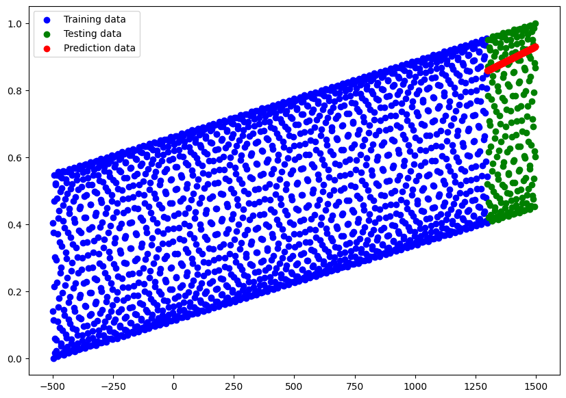

```python
y_scaled_preds7 = model.predict(X_test)

plot_predictions(X_train, y_scaled_train, X_test, y_scaled_test, y_scaled_preds7), plot_predictions(X_train, y_scaled_train, X_test, y_scaled_test, y_scaled_preds2)
```

Again, a small bit of improvement.

#### 6. Insufficient training/Overfitting on linear components

Let's try pulling up the number of epochs, by increasing the amount to train.

```python
tf.random.set_seed(35)

model = tf.keras.Sequential([
    tf.keras.layers.Dense(1)
])

# compile the model
model.compile(loss=tf.keras.losses.mae,
              optimizer=tf.keras.optimizers.Adam(0.0001),
              metrics=['mae'])

# fit model
model.fit(tf.expand_dims(X_train, axis=-1), y_scaled_train, epochs=500)
```

```
57/57 ━━━━━━━━━━━━━━━━━━━━ 1s 2ms/step - loss: 580.7787 - mae: 580.7787
57/57 ━━━━━━━━━━━━━━━━━━━━ 0s 2ms/step - loss: 577.7396 - mae: 577.7396
57/57 ━━━━━━━━━━━━━━━━━━━━ 0s 2ms/step - loss: 574.7151 - mae: 574.7151
57/57 ━━━━━━━━━━━━━━━━━━━━ 0s 2ms/step - loss: 571.6959 - mae: 571.6959
57/57 ━━━━━━━━━━━━━━━━━━━━ 0s 2ms/step - loss: 568.6787 - mae: 568.6787
57/57 ━━━━━━━━━━━━━━━━━━━━ 0s 2ms/step - loss: 565.6632 - mae: 565.6632
57/57 ━━━━━━━━━━━━━━━━━━━━ 0s 2ms/step - loss: 562.6484 - mae: 562.6484
57/57 ━━━━━━━━━━━━━━━━━━━━ 0s 3ms/step - loss: 559.6341 - mae: 559.6341
57/57 ━━━━━━━━━━━━━━━━━━━━ 0s 2ms/step - loss: 556.6202 - mae: 556.6202
57/57 ━━━━━━━━━━━━━━━━━━━━ 0s 2ms/step - loss: 553.6066 - mae: 553.6066
57/57 ━━━━━━━━━━━━━━━━━━━━ 0s 2ms/step - loss: 550.5936 - mae: 550.5936
57/57 ━━━━━━━━━━━━━━━━━━━━ 0s 2ms/step - loss: 547.5806 - mae: 547.5806
57/57 ━━━━━━━━━━━━━━━━━━━━ 0s 2ms/step - loss: 544.5680 - mae: 544.5680
57/57 ━━━━━━━━━━━━━━━━━━━━ 0s 2ms/step - loss: 541.5554 - mae: 541.5554
57/57 ━━━━━━━━━━━━━━━━━━━━ 0s 2ms/step - loss: 538.5429 - mae: 538.5429
57/57 ━━━━━━━━━━━━━━━━━━━━ 0s 2ms/step - loss: 535.5306 - mae: 535.5306
57/57 ━━━━━━━━━━━━━━━━━━━━ 0s 3ms/step - loss: 532.5182 - mae: 532.5182
57/57 ━━━━━━━━━━━━━━━━━━━━ 0s 3ms/step - loss: 529.5060 - mae: 529.5060
57/57 ━━━━━━━━━━━━━━━━━━━━ 0s 2ms/step - loss: 526.4938 - mae: 526.4938
57/57 ━━━━━━━━━━━━━━━━━━━━ 0s 2ms/step - loss: 523.4816 - mae: 523.4816
57/57 ━━━━━━━━━━━━━━━━━━━━ 0s 3ms/step - loss: 520.4694 - mae: 520.4694
57/57 ━━━━━━━━━━━━━━━━━━━━ 0s 2ms/step - loss: 517.4574 - mae: 517.4574
57/57 ━━━━━━━━━━━━━━━━━━━━ 0s 2ms/step - loss: 514.4454 - mae: 514.4454
57/57 ━━━━━━━━━━━━━━━━━━━━ 0s 2ms/step - loss: 511.4333 - mae: 511.4333
57/57 ━━━━━━━━━━━━━━━━━━━━ 0s 2ms/step - loss: 508.4214 - mae: 508.4214
57/57 ━━━━━━━━━━━━━━━━━━━━ 0s 3ms/step - loss: 505.4095 - mae: 505.4095
57/57 ━━━━━━━━━━━━━━━━━━━━ 0s 3ms/step - loss: 502.3975 - mae: 502.3975
57/57 ━━━━━━━━━━━━━━━━━━━━ 0s 2ms/step - loss: 499.3857 - mae: 499.3857
57/57 ━━━━━━━━━━━━━━━━━━━━ 0s 2ms/step - loss: 496.3738 - mae: 496.3738
57/57 ━━━━━━━━━━━━━━━━━━━━ 0s 2ms/step - loss: 493.3620 - mae: 493.3620
57/57 ━━━━━━━━━━━━━━━━━━━━ 0s 2ms/step - loss: 490.3503 - mae: 490.3503
57/57 ━━━━━━━━━━━━━━━━━━━━ 0s 2ms/step - loss: 487.3384 - mae: 487.3384
57/57 ━━━━━━━━━━━━━━━━━━━━ 0s 2ms/step - loss: 484.3267 - mae: 484.3267
57/57 ━━━━━━━━━━━━━━━━━━━━ 0s 2ms/step - loss: 481.3149 - mae: 481.3149
57/57 ━━━━━━━━━━━━━━━━━━━━ 0s 2ms/step - loss: 478.3032 - mae: 478.3032
57/57 ━━━━━━━━━━━━━━━━━━━━ 0s 2ms/step - loss: 475.2914 - mae: 475.2914
57/57 ━━━━━━━━━━━━━━━━━━━━ 0s 2ms/step - loss: 472.2796 - mae: 472.2796
57/57 ━━━━━━━━━━━━━━━━━━━━ 0s 2ms/step - loss: 469.2679 - mae: 469.2679
57/57 ━━━━━━━━━━━━━━━━━━━━ 0s 2ms/step - loss: 466.2562 - mae: 466.2562
57/57 ━━━━━━━━━━━━━━━━━━━━ 0s 2ms/step - loss: 463.2444 - mae: 463.2444
```

[output cut: 445 more lines]

```
57/57 ━━━━━━━━━━━━━━━━━━━━ 0s 2ms/step - loss: 0.1810 - mae: 0.1810
57/57 ━━━━━━━━━━━━━━━━━━━━ 0s 2ms/step - loss: 0.1807 - mae: 0.1807
57/57 ━━━━━━━━━━━━━━━━━━━━ 0s 2ms/step - loss: 0.1801 - mae: 0.1801
57/57 ━━━━━━━━━━━━━━━━━━━━ 0s 3ms/step - loss: 0.1801 - mae: 0.1801
57/57 ━━━━━━━━━━━━━━━━━━━━ 0s 2ms/step - loss: 0.1802 - mae: 0.1802
57/57 ━━━━━━━━━━━━━━━━━━━━ 0s 2ms/step - loss: 0.1806 - mae: 0.1806
57/57 ━━━━━━━━━━━━━━━━━━━━ 0s 2ms/step - loss: 0.1801 - mae: 0.1801
57/57 ━━━━━━━━━━━━━━━━━━━━ 0s 2ms/step - loss: 0.1799 - mae: 0.1799
57/57 ━━━━━━━━━━━━━━━━━━━━ 0s 2ms/step - loss: 0.1799 - mae: 0.1799
57/57 ━━━━━━━━━━━━━━━━━━━━ 0s 2ms/step - loss: 0.1809 - mae: 0.1809
57/57 ━━━━━━━━━━━━━━━━━━━━ 0s 4ms/step - loss: 0.1800 - mae: 0.1800
57/57 ━━━━━━━━━━━━━━━━━━━━ 0s 2ms/step - loss: 0.1799 - mae: 0.1799
57/57 ━━━━━━━━━━━━━━━━━━━━ 0s 2ms/step - loss: 0.1800 - mae: 0.1800
57/57 ━━━━━━━━━━━━━━━━━━━━ 0s 2ms/step - loss: 0.1812 - mae: 0.1812
57/57 ━━━━━━━━━━━━━━━━━━━━ 0s 2ms/step - loss: 0.1804 - mae: 0.1804
```

```
<keras.src.callbacks.history.History at 0x26713e635e0>
```

#### Model 8

```
7/7 ━━━━━━━━━━━━━━━━━━━━ 0s 7ms/step
```

```
(None, None)
```

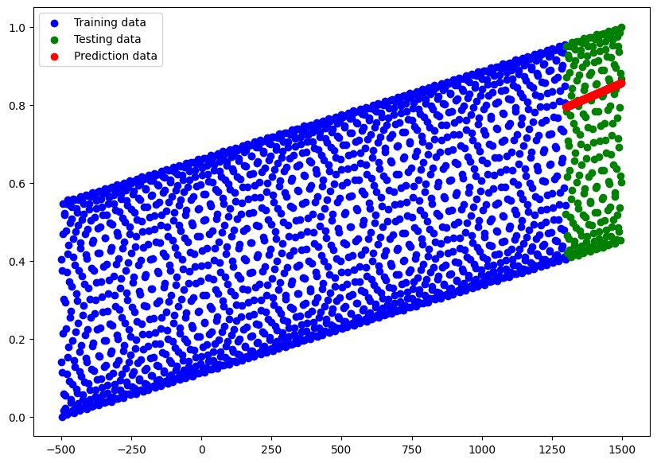

```python
y_scaled_preds8 = model.predict(X_test)

plot_predictions(X_train, y_scaled_train, X_test, y_scaled_test, y_scaled_preds8), plot_predictions(X_train, y_scaled_train, X_test, y_scaled_test, y_scaled_preds2)
```

Again, a very slight improvement on the prediction. This might only be substantial on models that lack complexity.

These experimentation povides some very fruitful qualities that leads closer to the answer. Let's try and fit all the improvement qualities into one model, and see its output.

The list of stuff to implement all together:

**1. Insufficient model complexity**

**2. Activation function issues**

**3. Normalizing X**

**5. Learning rate too high**

```python
# combine all improvement qualities into one model
from tensorflow.keras.layers import Dense, PReLU, ELU, Activation, Lambda

tf.random.set_seed(35)

def sinusoidal(x):
    return tf.sin(x)

# Create the model with multiple layers, and multiple nonlinear activation functions
model = tf.keras.Sequential([
    tf.keras.layers.Dense(128),
    PReLU(),

    Dense(128),
    ELU(alpha=1.0),

    Dense(128),
    Activation('softplus'),

    Dense(128),
    Lambda(sinusoidal),

    Dense(1)
])

model.compile(
    loss=tf.keras.losses.mae,
    optimizer=tf.keras.optimizers.Adam(learning_rate=0.001), # minimized learning rate of Adam
    metrics=['mae']
)

model.fit(tf.expand_dims(X_scaled_train, axis=-1), y_scaled_train, epochs=100) # train on X_scaled_train
```

```
57/57 ━━━━━━━━━━━━━━━━━━━━ 33s 6ms/step - loss: 0.4991 - mae: 0.4991
57/57 ━━━━━━━━━━━━━━━━━━━━ 0s 5ms/step - loss: 0.2031 - mae: 0.2031
57/57 ━━━━━━━━━━━━━━━━━━━━ 0s 5ms/step - loss: 0.2033 - mae: 0.2033
57/57 ━━━━━━━━━━━━━━━━━━━━ 0s 5ms/step - loss: 0.2041 - mae: 0.2041
57/57 ━━━━━━━━━━━━━━━━━━━━ 0s 5ms/step - loss: 0.2079 - mae: 0.2079
57/57 ━━━━━━━━━━━━━━━━━━━━ 0s 5ms/step - loss: 0.2044 - mae: 0.2044
57/57 ━━━━━━━━━━━━━━━━━━━━ 0s 6ms/step - loss: 0.2034 - mae: 0.2034
57/57 ━━━━━━━━━━━━━━━━━━━━ 0s 5ms/step - loss: 0.2033 - mae: 0.2033
57/57 ━━━━━━━━━━━━━━━━━━━━ 0s 5ms/step - loss: 0.2041 - mae: 0.2041
57/57 ━━━━━━━━━━━━━━━━━━━━ 0s 5ms/step - loss: 0.2053 - mae: 0.2053
57/57 ━━━━━━━━━━━━━━━━━━━━ 0s 5ms/step - loss: 0.2060 - mae: 0.2060
57/57 ━━━━━━━━━━━━━━━━━━━━ 0s 4ms/step - loss: 0.2056 - mae: 0.2056
57/57 ━━━━━━━━━━━━━━━━━━━━ 0s 4ms/step - loss: 0.2070 - mae: 0.2070
57/57 ━━━━━━━━━━━━━━━━━━━━ 0s 4ms/step - loss: 0.2041 - mae: 0.2041
57/57 ━━━━━━━━━━━━━━━━━━━━ 0s 4ms/step - loss: 0.2041 - mae: 0.2041
57/57 ━━━━━━━━━━━━━━━━━━━━ 0s 4ms/step - loss: 0.2059 - mae: 0.2059
57/57 ━━━━━━━━━━━━━━━━━━━━ 0s 4ms/step - loss: 0.2056 - mae: 0.2056
57/57 ━━━━━━━━━━━━━━━━━━━━ 0s 5ms/step - loss: 0.2052 - mae: 0.2052
57/57 ━━━━━━━━━━━━━━━━━━━━ 0s 4ms/step - loss: 0.2047 - mae: 0.2047
57/57 ━━━━━━━━━━━━━━━━━━━━ 0s 4ms/step - loss: 0.2040 - mae: 0.2040
57/57 ━━━━━━━━━━━━━━━━━━━━ 0s 5ms/step - loss: 0.2035 - mae: 0.2035
57/57 ━━━━━━━━━━━━━━━━━━━━ 0s 4ms/step - loss: 0.2041 - mae: 0.2041
57/57 ━━━━━━━━━━━━━━━━━━━━ 0s 4ms/step - loss: 0.2038 - mae: 0.2038
57/57 ━━━━━━━━━━━━━━━━━━━━ 0s 4ms/step - loss: 0.2034 - mae: 0.2034
57/57 ━━━━━━━━━━━━━━━━━━━━ 0s 5ms/step - loss: 0.2090 - mae: 0.2090
57/57 ━━━━━━━━━━━━━━━━━━━━ 0s 4ms/step - loss: 0.2051 - mae: 0.2051
57/57 ━━━━━━━━━━━━━━━━━━━━ 0s 4ms/step - loss: 0.2043 - mae: 0.2043
57/57 ━━━━━━━━━━━━━━━━━━━━ 0s 4ms/step - loss: 0.2050 - mae: 0.2050
57/57 ━━━━━━━━━━━━━━━━━━━━ 0s 4ms/step - loss: 0.2027 - mae: 0.2027
57/57 ━━━━━━━━━━━━━━━━━━━━ 0s 4ms/step - loss: 0.2019 - mae: 0.2019
57/57 ━━━━━━━━━━━━━━━━━━━━ 0s 4ms/step - loss: 0.2001 - mae: 0.2001
57/57 ━━━━━━━━━━━━━━━━━━━━ 0s 5ms/step - loss: 0.2013 - mae: 0.2013
57/57 ━━━━━━━━━━━━━━━━━━━━ 0s 4ms/step - loss: 0.1998 - mae: 0.1998
57/57 ━━━━━━━━━━━━━━━━━━━━ 0s 5ms/step - loss: 0.1999 - mae: 0.1999
57/57 ━━━━━━━━━━━━━━━━━━━━ 0s 4ms/step - loss: 0.1995 - mae: 0.1995
57/57 ━━━━━━━━━━━━━━━━━━━━ 0s 4ms/step - loss: 0.1994 - mae: 0.1994
57/57 ━━━━━━━━━━━━━━━━━━━━ 0s 5ms/step - loss: 0.2006 - mae: 0.2006
57/57 ━━━━━━━━━━━━━━━━━━━━ 0s 4ms/step - loss: 0.1994 - mae: 0.1994
57/57 ━━━━━━━━━━━━━━━━━━━━ 0s 4ms/step - loss: 0.1992 - mae: 0.1992
57/57 ━━━━━━━━━━━━━━━━━━━━ 0s 5ms/step - loss: 0.2005 - mae: 0.2005
```

[output cut: 45 more lines]

```
57/57 ━━━━━━━━━━━━━━━━━━━━ 0s 5ms/step - loss: 0.1978 - mae: 0.1978
57/57 ━━━━━━━━━━━━━━━━━━━━ 0s 5ms/step - loss: 0.1978 - mae: 0.1978
57/57 ━━━━━━━━━━━━━━━━━━━━ 0s 5ms/step - loss: 0.1977 - mae: 0.1977
57/57 ━━━━━━━━━━━━━━━━━━━━ 0s 5ms/step - loss: 0.1980 - mae: 0.1980
57/57 ━━━━━━━━━━━━━━━━━━━━ 0s 5ms/step - loss: 0.1975 - mae: 0.1975
57/57 ━━━━━━━━━━━━━━━━━━━━ 0s 5ms/step - loss: 0.2011 - mae: 0.2011
57/57 ━━━━━━━━━━━━━━━━━━━━ 0s 4ms/step - loss: 0.2039 - mae: 0.2039
57/57 ━━━━━━━━━━━━━━━━━━━━ 0s 5ms/step - loss: 0.1976 - mae: 0.1976
57/57 ━━━━━━━━━━━━━━━━━━━━ 0s 5ms/step - loss: 0.1997 - mae: 0.1997
57/57 ━━━━━━━━━━━━━━━━━━━━ 0s 4ms/step - loss: 0.1998 - mae: 0.1998
57/57 ━━━━━━━━━━━━━━━━━━━━ 0s 5ms/step - loss: 0.1986 - mae: 0.1986
57/57 ━━━━━━━━━━━━━━━━━━━━ 0s 5ms/step - loss: 0.1995 - mae: 0.1995
57/57 ━━━━━━━━━━━━━━━━━━━━ 0s 5ms/step - loss: 0.1972 - mae: 0.1972
57/57 ━━━━━━━━━━━━━━━━━━━━ 0s 5ms/step - loss: 0.1993 - mae: 0.1993
57/57 ━━━━━━━━━━━━━━━━━━━━ 0s 4ms/step - loss: 0.1980 - mae: 0.1980
```

```
<keras.src.callbacks.history.History at 0x2671687f700>
```

```
7/7 ━━━━━━━━━━━━━━━━━━━━ 0s 15ms/step
```

```
(None, None)
```

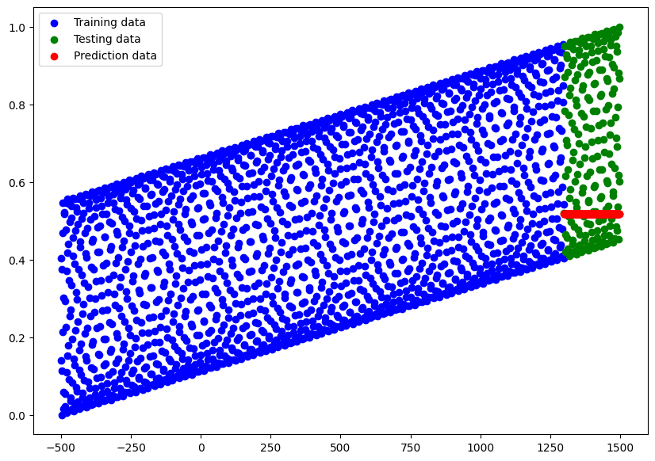

```python
y_scaled_preds9 = model.predict(X_scaled_test)

plot_predictions(X_train, y_scaled_train, X_test, y_scaled_test, y_scaled_preds9), plot_predictions(X_train, y_scaled_train, X_test, y_scaled_test, y_scaled_preds2)
```

Hmmm... this isn't helpful. Where did the curviness of the nonlinear activations go?

I'll pull back model 4, where we did the nonlinear activations in the model. See how we can manipulate it to become more accurate.

```python
from tensorflow.keras.layers import Dense, PReLU, ELU, Activation, Lambda

# Set seed
tf.random.set_seed(35)

# Custom Sinusoidal Activation Function
def sinusoidal(x):
    return tf.sin(x)

# Create the model
model = tf.keras.Sequential([
    tf.keras.layers.Dense(128),  # Input Layer
    # 1. PReLU Activation
    PReLU(),

    # 2. ELU Activation
    Dense(128),  # Fully connected layer
    ELU(alpha=1.0),

    # 3. Softplus Activation
    Dense(128),
    Activation('softplus'),

    # 4. Sinusoidal Activation
    Dense(128),
    Lambda(sinusoidal),

    # Output Layer
    Dense(1)
])

# Compile the model
model.compile(
    loss=tf.keras.losses.mae,
    optimizer=tf.keras.optimizers.Adam(learning_rate=0.0001),
    metrics=['mae']
)

# Fit the model
model.fit(tf.expand_dims(X_train, axis=-1), y_scaled_train, epochs=100)
```

```
57/57 ━━━━━━━━━━━━━━━━━━━━ 4s 21ms/step - loss: 0.6349 - mae: 0.6349
57/57 ━━━━━━━━━━━━━━━━━━━━ 0s 7ms/step - loss: 0.4628 - mae: 0.4628
57/57 ━━━━━━━━━━━━━━━━━━━━ 0s 5ms/step - loss: 0.3941 - mae: 0.3941
57/57 ━━━━━━━━━━━━━━━━━━━━ 0s 6ms/step - loss: 0.4280 - mae: 0.4280
57/57 ━━━━━━━━━━━━━━━━━━━━ 0s 5ms/step - loss: 0.4576 - mae: 0.4576
57/57 ━━━━━━━━━━━━━━━━━━━━ 0s 4ms/step - loss: 0.4802 - mae: 0.4802
57/57 ━━━━━━━━━━━━━━━━━━━━ 0s 4ms/step - loss: 0.3830 - mae: 0.3830
57/57 ━━━━━━━━━━━━━━━━━━━━ 0s 4ms/step - loss: 0.4388 - mae: 0.4388
57/57 ━━━━━━━━━━━━━━━━━━━━ 0s 3ms/step - loss: 0.4034 - mae: 0.4034
57/57 ━━━━━━━━━━━━━━━━━━━━ 0s 4ms/step - loss: 0.3917 - mae: 0.3917
57/57 ━━━━━━━━━━━━━━━━━━━━ 0s 3ms/step - loss: 0.4260 - mae: 0.4260
57/57 ━━━━━━━━━━━━━━━━━━━━ 0s 3ms/step - loss: 0.4353 - mae: 0.4353
57/57 ━━━━━━━━━━━━━━━━━━━━ 0s 3ms/step - loss: 0.4225 - mae: 0.4225
57/57 ━━━━━━━━━━━━━━━━━━━━ 0s 3ms/step - loss: 0.4272 - mae: 0.4272
57/57 ━━━━━━━━━━━━━━━━━━━━ 0s 3ms/step - loss: 0.4212 - mae: 0.4212
57/57 ━━━━━━━━━━━━━━━━━━━━ 0s 3ms/step - loss: 0.4161 - mae: 0.4161
57/57 ━━━━━━━━━━━━━━━━━━━━ 0s 2ms/step - loss: 0.4276 - mae: 0.4276
57/57 ━━━━━━━━━━━━━━━━━━━━ 0s 3ms/step - loss: 0.4130 - mae: 0.4130
57/57 ━━━━━━━━━━━━━━━━━━━━ 0s 3ms/step - loss: 0.4224 - mae: 0.4224
57/57 ━━━━━━━━━━━━━━━━━━━━ 0s 3ms/step - loss: 0.3616 - mae: 0.3616
57/57 ━━━━━━━━━━━━━━━━━━━━ 0s 3ms/step - loss: 0.3868 - mae: 0.3868
57/57 ━━━━━━━━━━━━━━━━━━━━ 0s 4ms/step - loss: 0.3628 - mae: 0.3628
57/57 ━━━━━━━━━━━━━━━━━━━━ 0s 3ms/step - loss: 0.3822 - mae: 0.3822
57/57 ━━━━━━━━━━━━━━━━━━━━ 0s 3ms/step - loss: 0.3550 - mae: 0.3550
57/57 ━━━━━━━━━━━━━━━━━━━━ 0s 3ms/step - loss: 0.4015 - mae: 0.4015
57/57 ━━━━━━━━━━━━━━━━━━━━ 0s 3ms/step - loss: 0.3513 - mae: 0.3513
57/57 ━━━━━━━━━━━━━━━━━━━━ 0s 3ms/step - loss: 0.3113 - mae: 0.3113
57/57 ━━━━━━━━━━━━━━━━━━━━ 0s 3ms/step - loss: 0.3420 - mae: 0.3420
57/57 ━━━━━━━━━━━━━━━━━━━━ 0s 5ms/step - loss: 0.3339 - mae: 0.3339
57/57 ━━━━━━━━━━━━━━━━━━━━ 0s 3ms/step - loss: 0.3556 - mae: 0.3556
57/57 ━━━━━━━━━━━━━━━━━━━━ 0s 3ms/step - loss: 0.3426 - mae: 0.3426
57/57 ━━━━━━━━━━━━━━━━━━━━ 0s 3ms/step - loss: 0.3403 - mae: 0.3403
57/57 ━━━━━━━━━━━━━━━━━━━━ 0s 3ms/step - loss: 0.3144 - mae: 0.3144
57/57 ━━━━━━━━━━━━━━━━━━━━ 0s 3ms/step - loss: 0.3357 - mae: 0.3357
57/57 ━━━━━━━━━━━━━━━━━━━━ 0s 4ms/step - loss: 0.3162 - mae: 0.3162
57/57 ━━━━━━━━━━━━━━━━━━━━ 0s 3ms/step - loss: 0.3258 - mae: 0.3258
57/57 ━━━━━━━━━━━━━━━━━━━━ 0s 3ms/step - loss: 0.3230 - mae: 0.3230
57/57 ━━━━━━━━━━━━━━━━━━━━ 0s 3ms/step - loss: 0.3231 - mae: 0.3231
57/57 ━━━━━━━━━━━━━━━━━━━━ 0s 4ms/step - loss: 0.3063 - mae: 0.3063
57/57 ━━━━━━━━━━━━━━━━━━━━ 0s 4ms/step - loss: 0.3462 - mae: 0.3462
```

[output cut: 45 more lines]

```
57/57 ━━━━━━━━━━━━━━━━━━━━ 0s 3ms/step - loss: 0.2205 - mae: 0.2205
57/57 ━━━━━━━━━━━━━━━━━━━━ 0s 3ms/step - loss: 0.2466 - mae: 0.2466
57/57 ━━━━━━━━━━━━━━━━━━━━ 0s 3ms/step - loss: 0.2265 - mae: 0.2265
57/57 ━━━━━━━━━━━━━━━━━━━━ 0s 3ms/step - loss: 0.2303 - mae: 0.2303
57/57 ━━━━━━━━━━━━━━━━━━━━ 0s 3ms/step - loss: 0.2245 - mae: 0.2245
57/57 ━━━━━━━━━━━━━━━━━━━━ 0s 3ms/step - loss: 0.2178 - mae: 0.2178
57/57 ━━━━━━━━━━━━━━━━━━━━ 0s 3ms/step - loss: 0.2335 - mae: 0.2335
57/57 ━━━━━━━━━━━━━━━━━━━━ 0s 3ms/step - loss: 0.2177 - mae: 0.2177
57/57 ━━━━━━━━━━━━━━━━━━━━ 0s 3ms/step - loss: 0.2195 - mae: 0.2195
57/57 ━━━━━━━━━━━━━━━━━━━━ 0s 3ms/step - loss: 0.2375 - mae: 0.2375
57/57 ━━━━━━━━━━━━━━━━━━━━ 0s 3ms/step - loss: 0.2429 - mae: 0.2429
57/57 ━━━━━━━━━━━━━━━━━━━━ 0s 3ms/step - loss: 0.2253 - mae: 0.2253
57/57 ━━━━━━━━━━━━━━━━━━━━ 0s 3ms/step - loss: 0.2341 - mae: 0.2341
57/57 ━━━━━━━━━━━━━━━━━━━━ 0s 3ms/step - loss: 0.2304 - mae: 0.2304
57/57 ━━━━━━━━━━━━━━━━━━━━ 0s 3ms/step - loss: 0.2397 - mae: 0.2397
```

```
<keras.src.callbacks.history.History at 0x2670d7b3ac0>
```

```
7/7 ━━━━━━━━━━━━━━━━━━━━ 0s 22ms/step
```

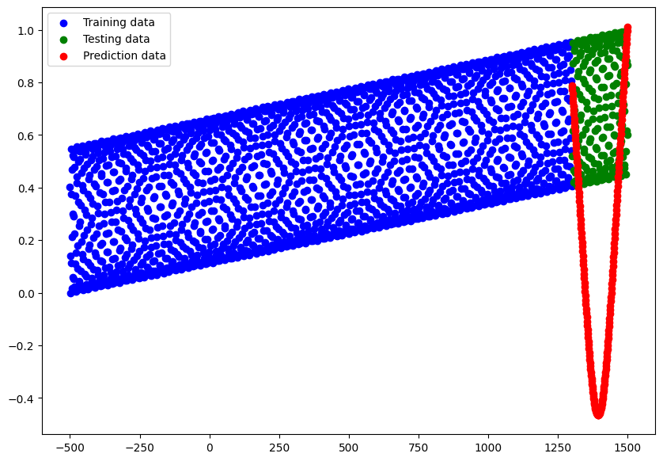

```python
y_scaled_preds4 = model.predict(X_test)

plot_predictions(X_train, y_scaled_train, X_test, y_scaled_test, y_scaled_preds4)
```

Let's remove one nonlinear activations at a time and see which brings the model closer to ideal.

```python
from tensorflow.keras.layers import Dense, PReLU, ELU, Activation, Lambda

# Set seed
tf.random.set_seed(35)

# Custom Sinusoidal Activation Function
def sinusoidal(x):
    return tf.sin(x)

# Create the model
model = tf.keras.Sequential([
    tf.keras.layers.Dense(128),  # Input Layer
    # 1. PReLU Activation
    PReLU(),

    # 3. Softplus Activation
    Dense(128),
    Activation('softplus'),

    # 4. Sinusoidal Activation
    Dense(128),
    Lambda(sinusoidal),

    # Output Layer
    Dense(1)
])

# Compile the model
model.compile(
    loss=tf.keras.losses.mae,
    optimizer=tf.keras.optimizers.Adam(learning_rate=0.0001),
    metrics=['mae']
)

# Fit the model
model.fit(tf.expand_dims(X_train, axis=-1), y_scaled_train, epochs=100)
```

```
57/57 ━━━━━━━━━━━━━━━━━━━━ 3s 3ms/step - loss: 0.7737 - mae: 0.7737
57/57 ━━━━━━━━━━━━━━━━━━━━ 0s 3ms/step - loss: 0.6274 - mae: 0.6274
57/57 ━━━━━━━━━━━━━━━━━━━━ 0s 3ms/step - loss: 0.5397 - mae: 0.5397
57/57 ━━━━━━━━━━━━━━━━━━━━ 0s 2ms/step - loss: 0.5074 - mae: 0.5074
57/57 ━━━━━━━━━━━━━━━━━━━━ 0s 3ms/step - loss: 0.4809 - mae: 0.4809
57/57 ━━━━━━━━━━━━━━━━━━━━ 0s 3ms/step - loss: 0.5182 - mae: 0.5182
57/57 ━━━━━━━━━━━━━━━━━━━━ 0s 3ms/step - loss: 0.5669 - mae: 0.5669
57/57 ━━━━━━━━━━━━━━━━━━━━ 0s 3ms/step - loss: 0.5287 - mae: 0.5287
57/57 ━━━━━━━━━━━━━━━━━━━━ 0s 2ms/step - loss: 0.4863 - mae: 0.4863
57/57 ━━━━━━━━━━━━━━━━━━━━ 0s 4ms/step - loss: 0.5142 - mae: 0.5142
57/57 ━━━━━━━━━━━━━━━━━━━━ 0s 4ms/step - loss: 0.4929 - mae: 0.4929
57/57 ━━━━━━━━━━━━━━━━━━━━ 0s 3ms/step - loss: 0.4797 - mae: 0.4797
57/57 ━━━━━━━━━━━━━━━━━━━━ 0s 3ms/step - loss: 0.4861 - mae: 0.4861
57/57 ━━━━━━━━━━━━━━━━━━━━ 0s 2ms/step - loss: 0.4760 - mae: 0.4760
57/57 ━━━━━━━━━━━━━━━━━━━━ 0s 5ms/step - loss: 0.5214 - mae: 0.5214
57/57 ━━━━━━━━━━━━━━━━━━━━ 0s 3ms/step - loss: 0.4319 - mae: 0.4319
57/57 ━━━━━━━━━━━━━━━━━━━━ 0s 3ms/step - loss: 0.4318 - mae: 0.4318
57/57 ━━━━━━━━━━━━━━━━━━━━ 0s 3ms/step - loss: 0.4713 - mae: 0.4713
57/57 ━━━━━━━━━━━━━━━━━━━━ 0s 3ms/step - loss: 0.4124 - mae: 0.4124
57/57 ━━━━━━━━━━━━━━━━━━━━ 0s 2ms/step - loss: 0.4696 - mae: 0.4696
57/57 ━━━━━━━━━━━━━━━━━━━━ 0s 2ms/step - loss: 0.4685 - mae: 0.4685
57/57 ━━━━━━━━━━━━━━━━━━━━ 0s 3ms/step - loss: 0.4389 - mae: 0.4389
57/57 ━━━━━━━━━━━━━━━━━━━━ 0s 3ms/step - loss: 0.4588 - mae: 0.4588
57/57 ━━━━━━━━━━━━━━━━━━━━ 0s 2ms/step - loss: 0.4475 - mae: 0.4475
57/57 ━━━━━━━━━━━━━━━━━━━━ 0s 3ms/step - loss: 0.4704 - mae: 0.4704
57/57 ━━━━━━━━━━━━━━━━━━━━ 0s 2ms/step - loss: 0.4685 - mae: 0.4685
57/57 ━━━━━━━━━━━━━━━━━━━━ 0s 2ms/step - loss: 0.4367 - mae: 0.4367
57/57 ━━━━━━━━━━━━━━━━━━━━ 0s 3ms/step - loss: 0.3849 - mae: 0.3849
57/57 ━━━━━━━━━━━━━━━━━━━━ 0s 3ms/step - loss: 0.3919 - mae: 0.3919
57/57 ━━━━━━━━━━━━━━━━━━━━ 0s 4ms/step - loss: 0.3965 - mae: 0.3965
57/57 ━━━━━━━━━━━━━━━━━━━━ 0s 2ms/step - loss: 0.4093 - mae: 0.4093
57/57 ━━━━━━━━━━━━━━━━━━━━ 0s 2ms/step - loss: 0.3982 - mae: 0.3982
57/57 ━━━━━━━━━━━━━━━━━━━━ 0s 3ms/step - loss: 0.4071 - mae: 0.4071
57/57 ━━━━━━━━━━━━━━━━━━━━ 0s 3ms/step - loss: 0.3791 - mae: 0.3791
57/57 ━━━━━━━━━━━━━━━━━━━━ 0s 3ms/step - loss: 0.3932 - mae: 0.3932
57/57 ━━━━━━━━━━━━━━━━━━━━ 0s 2ms/step - loss: 0.3851 - mae: 0.3851
57/57 ━━━━━━━━━━━━━━━━━━━━ 0s 2ms/step - loss: 0.3872 - mae: 0.3872
57/57 ━━━━━━━━━━━━━━━━━━━━ 0s 3ms/step - loss: 0.3872 - mae: 0.3872
57/57 ━━━━━━━━━━━━━━━━━━━━ 0s 3ms/step - loss: 0.3951 - mae: 0.3951
57/57 ━━━━━━━━━━━━━━━━━━━━ 0s 2ms/step - loss: 0.4238 - mae: 0.4238
```

[output cut: 45 more lines]

```
57/57 ━━━━━━━━━━━━━━━━━━━━ 0s 2ms/step - loss: 0.2679 - mae: 0.2679
57/57 ━━━━━━━━━━━━━━━━━━━━ 0s 2ms/step - loss: 0.2816 - mae: 0.2816
57/57 ━━━━━━━━━━━━━━━━━━━━ 0s 3ms/step - loss: 0.2532 - mae: 0.2532
57/57 ━━━━━━━━━━━━━━━━━━━━ 0s 3ms/step - loss: 0.2570 - mae: 0.2570
57/57 ━━━━━━━━━━━━━━━━━━━━ 0s 3ms/step - loss: 0.2691 - mae: 0.2691
57/57 ━━━━━━━━━━━━━━━━━━━━ 0s 3ms/step - loss: 0.2581 - mae: 0.2581
57/57 ━━━━━━━━━━━━━━━━━━━━ 0s 3ms/step - loss: 0.2567 - mae: 0.2567
57/57 ━━━━━━━━━━━━━━━━━━━━ 0s 3ms/step - loss: 0.2429 - mae: 0.2429
57/57 ━━━━━━━━━━━━━━━━━━━━ 0s 3ms/step - loss: 0.2453 - mae: 0.2453
57/57 ━━━━━━━━━━━━━━━━━━━━ 0s 2ms/step - loss: 0.2390 - mae: 0.2390
57/57 ━━━━━━━━━━━━━━━━━━━━ 0s 2ms/step - loss: 0.2431 - mae: 0.2431
57/57 ━━━━━━━━━━━━━━━━━━━━ 0s 2ms/step - loss: 0.2505 - mae: 0.2505
57/57 ━━━━━━━━━━━━━━━━━━━━ 0s 3ms/step - loss: 0.2557 - mae: 0.2557
57/57 ━━━━━━━━━━━━━━━━━━━━ 0s 3ms/step - loss: 0.2563 - mae: 0.2563
57/57 ━━━━━━━━━━━━━━━━━━━━ 0s 3ms/step - loss: 0.2507 - mae: 0.2507
```

```
<keras.src.callbacks.history.History at 0x2670daa2b80>
```

#### Model 10

```
7/7 ━━━━━━━━━━━━━━━━━━━━ 0s 25ms/step
```

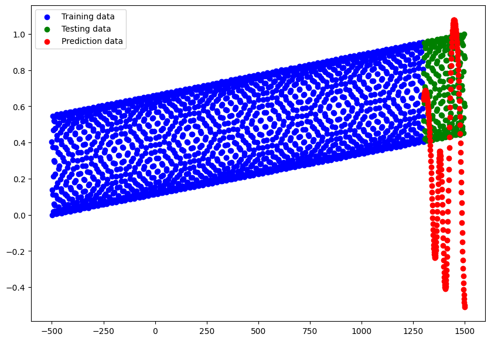

```python
y_scaled_preds10 = model.predict(X_test)

plot_predictions(X_train, y_scaled_train, X_test, y_scaled_test, y_scaled_preds10)
```

```python
from tensorflow.keras.layers import Dense, PReLU, ELU, Activation, Lambda

# Set seed
tf.random.set_seed(35)

# Custom Sinusoidal Activation Function
def sinusoidal(x):
    return tf.sin(x)

# Create the model
model = tf.keras.Sequential([
    tf.keras.layers.Dense(128),  # Input Layer
    # 1. PReLU Activation
    PReLU(),

    # 4. Sinusoidal Activation
    Dense(128),
    Lambda(sinusoidal),

    # Output Layer
    Dense(1)
])

# Compile the model
model.compile(
    loss=tf.keras.losses.mae,
    optimizer=tf.keras.optimizers.Adam(learning_rate=0.0001),
    metrics=['mae']
)

# Fit the model
model.fit(tf.expand_dims(X_train, axis=-1), y_scaled_train, epochs=100)
```

```
57/57 ━━━━━━━━━━━━━━━━━━━━ 5s 4ms/step - loss: 0.7452 - mae: 0.7452
57/57 ━━━━━━━━━━━━━━━━━━━━ 0s 4ms/step - loss: 0.5643 - mae: 0.5643
57/57 ━━━━━━━━━━━━━━━━━━━━ 0s 5ms/step - loss: 0.5210 - mae: 0.5210
57/57 ━━━━━━━━━━━━━━━━━━━━ 0s 6ms/step - loss: 0.5435 - mae: 0.5435
57/57 ━━━━━━━━━━━━━━━━━━━━ 0s 4ms/step - loss: 0.4651 - mae: 0.4651
57/57 ━━━━━━━━━━━━━━━━━━━━ 0s 5ms/step - loss: 0.5202 - mae: 0.5202
57/57 ━━━━━━━━━━━━━━━━━━━━ 0s 4ms/step - loss: 0.4379 - mae: 0.4379
57/57 ━━━━━━━━━━━━━━━━━━━━ 0s 4ms/step - loss: 0.4667 - mae: 0.4667
57/57 ━━━━━━━━━━━━━━━━━━━━ 0s 5ms/step - loss: 0.4632 - mae: 0.4632
57/57 ━━━━━━━━━━━━━━━━━━━━ 0s 6ms/step - loss: 0.4745 - mae: 0.4745
57/57 ━━━━━━━━━━━━━━━━━━━━ 0s 5ms/step - loss: 0.4780 - mae: 0.4780
57/57 ━━━━━━━━━━━━━━━━━━━━ 0s 5ms/step - loss: 0.4729 - mae: 0.4729
57/57 ━━━━━━━━━━━━━━━━━━━━ 0s 4ms/step - loss: 0.4363 - mae: 0.4363
57/57 ━━━━━━━━━━━━━━━━━━━━ 0s 4ms/step - loss: 0.4495 - mae: 0.4495
57/57 ━━━━━━━━━━━━━━━━━━━━ 0s 4ms/step - loss: 0.4263 - mae: 0.4263
57/57 ━━━━━━━━━━━━━━━━━━━━ 0s 4ms/step - loss: 0.4496 - mae: 0.4496
57/57 ━━━━━━━━━━━━━━━━━━━━ 0s 5ms/step - loss: 0.3973 - mae: 0.3973
57/57 ━━━━━━━━━━━━━━━━━━━━ 0s 5ms/step - loss: 0.4197 - mae: 0.4197
57/57 ━━━━━━━━━━━━━━━━━━━━ 0s 4ms/step - loss: 0.4320 - mae: 0.4320
57/57 ━━━━━━━━━━━━━━━━━━━━ 0s 4ms/step - loss: 0.3934 - mae: 0.3934
57/57 ━━━━━━━━━━━━━━━━━━━━ 0s 4ms/step - loss: 0.4272 - mae: 0.4272
57/57 ━━━━━━━━━━━━━━━━━━━━ 0s 5ms/step - loss: 0.3624 - mae: 0.3624
57/57 ━━━━━━━━━━━━━━━━━━━━ 0s 4ms/step - loss: 0.3905 - mae: 0.3905
57/57 ━━━━━━━━━━━━━━━━━━━━ 0s 5ms/step - loss: 0.3697 - mae: 0.3697
57/57 ━━━━━━━━━━━━━━━━━━━━ 0s 5ms/step - loss: 0.3611 - mae: 0.3611
57/57 ━━━━━━━━━━━━━━━━━━━━ 0s 4ms/step - loss: 0.3457 - mae: 0.3457
57/57 ━━━━━━━━━━━━━━━━━━━━ 0s 4ms/step - loss: 0.3644 - mae: 0.3644
57/57 ━━━━━━━━━━━━━━━━━━━━ 0s 4ms/step - loss: 0.3431 - mae: 0.3431
57/57 ━━━━━━━━━━━━━━━━━━━━ 0s 5ms/step - loss: 0.3799 - mae: 0.3799
57/57 ━━━━━━━━━━━━━━━━━━━━ 0s 4ms/step - loss: 0.3551 - mae: 0.3551
57/57 ━━━━━━━━━━━━━━━━━━━━ 0s 4ms/step - loss: 0.3292 - mae: 0.3292
57/57 ━━━━━━━━━━━━━━━━━━━━ 0s 6ms/step - loss: 0.3345 - mae: 0.3345
57/57 ━━━━━━━━━━━━━━━━━━━━ 1s 4ms/step - loss: 0.3136 - mae: 0.3136
57/57 ━━━━━━━━━━━━━━━━━━━━ 0s 5ms/step - loss: 0.3352 - mae: 0.3352
57/57 ━━━━━━━━━━━━━━━━━━━━ 0s 5ms/step - loss: 0.3340 - mae: 0.3340
57/57 ━━━━━━━━━━━━━━━━━━━━ 0s 4ms/step - loss: 0.3277 - mae: 0.3277
57/57 ━━━━━━━━━━━━━━━━━━━━ 0s 4ms/step - loss: 0.3203 - mae: 0.3203
57/57 ━━━━━━━━━━━━━━━━━━━━ 0s 4ms/step - loss: 0.3117 - mae: 0.3117
57/57 ━━━━━━━━━━━━━━━━━━━━ 0s 5ms/step - loss: 0.3158 - mae: 0.3158
57/57 ━━━━━━━━━━━━━━━━━━━━ 0s 4ms/step - loss: 0.3312 - mae: 0.3312
```

[output cut: 45 more lines]

```
57/57 ━━━━━━━━━━━━━━━━━━━━ 0s 4ms/step - loss: 0.2272 - mae: 0.2272
57/57 ━━━━━━━━━━━━━━━━━━━━ 0s 4ms/step - loss: 0.2223 - mae: 0.2223
57/57 ━━━━━━━━━━━━━━━━━━━━ 0s 4ms/step - loss: 0.2244 - mae: 0.2244
57/57 ━━━━━━━━━━━━━━━━━━━━ 0s 5ms/step - loss: 0.2236 - mae: 0.2236
57/57 ━━━━━━━━━━━━━━━━━━━━ 0s 5ms/step - loss: 0.2236 - mae: 0.2236
57/57 ━━━━━━━━━━━━━━━━━━━━ 0s 4ms/step - loss: 0.2184 - mae: 0.2184
57/57 ━━━━━━━━━━━━━━━━━━━━ 0s 5ms/step - loss: 0.2176 - mae: 0.2176
57/57 ━━━━━━━━━━━━━━━━━━━━ 0s 4ms/step - loss: 0.2120 - mae: 0.2120
57/57 ━━━━━━━━━━━━━━━━━━━━ 0s 4ms/step - loss: 0.2147 - mae: 0.2147
57/57 ━━━━━━━━━━━━━━━━━━━━ 0s 5ms/step - loss: 0.2115 - mae: 0.2115
57/57 ━━━━━━━━━━━━━━━━━━━━ 0s 4ms/step - loss: 0.2160 - mae: 0.2160
57/57 ━━━━━━━━━━━━━━━━━━━━ 0s 4ms/step - loss: 0.2125 - mae: 0.2125
57/57 ━━━━━━━━━━━━━━━━━━━━ 0s 4ms/step - loss: 0.2170 - mae: 0.2170
57/57 ━━━━━━━━━━━━━━━━━━━━ 0s 4ms/step - loss: 0.2172 - mae: 0.2172
57/57 ━━━━━━━━━━━━━━━━━━━━ 0s 5ms/step - loss: 0.2101 - mae: 0.2101
```

```
<keras.src.callbacks.history.History at 0x2671dbcea60>
```

#### Model 11

```
7/7 ━━━━━━━━━━━━━━━━━━━━ 0s 31ms/step
```

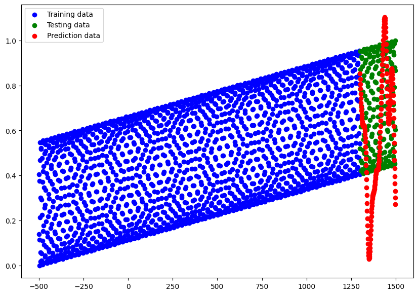

```python
y_scaled_preds11 = model.predict(X_test)

plot_predictions(X_train, y_scaled_train, X_test, y_scaled_test, y_scaled_preds11)
```

Seems removing `softplus` has yieled closer results. And I also found out that `sinusoidal` has proved very effective in prediction. As without it, it causes the model to predict linearly.

There's going to be a lot of fiddling, so I'll list all the changes I've made in sequential order, and what changed in the predictions:

**1. Remove PreLU layer**: More prediction points overlaying the truth labels, also less negative prediction values. *Loss: 0.2019*

**2. Move PreLU under Sinusoidal**: Prediction values don't follow a visible line, with more vareity. It's getting close to the variety needed to predict the truth values. *Loss: 0.1755*

**3. Softmax 128 neurons under PreLU, and under Sinusoidal**: Prediction values are less spread, and starts congregating an area of the value predictions. Get's closer to truth values. *Loss: 0.1784*

**4. Softmax neurons reduced to 64**: Not much different than when it had 128 neurons. *Loss: 0.1740*

**5. *CHANGED* Sinusoidal neurons to 256**: Loss is tiny bit higher, but values is similar to when it had 128 Neurons. *Loss: 0.1801*

**6. *REMOVED* Add ELU with 128 neurons at the last layer**: Slight decrease in accuracy. *Loss: 0.1801*

**7. *REMOVED* ELU 256 neurons placed as first layer**: Within data range, but its variety in values is not wide enough. *Loss: 0.1937*

**8. *REMOVED* ELU with 512 neurons instead**: Reduced accuracy. *Loss: 0.1943*

**9. *REMVOED* ELU with 512 neurons is replaced with Sinusoidal**: Slight reduced accuracy. Seems like ELU doesn't work with our prediction goals. *Loss: 0.1825*

**10. *CHANGED* Increase Sinusoidal 256 > 512, and PreLU 128 > 256**: Variety of data prediction shrank, not ideal. *Loss: 0.1840*

**11. New Sinusoidal 128 neurons betwwen PreLU, and Softplus**: No difference than the previous. *Loss: 0.1583*

**12. *CHANGED* Sinusoidal returns from 512 > 256, and PreLU 256 > 128 while keeping the new Sinusoidal 128**: Lack of variety in value for data prediction. *Loss: 0.1792*

**13. Set Sinusoidal, PreLU, and new Sinusoidal layers to 128 neurons**: Values and loss getting a tiny bit smaller. Predicted values trend smaller the bigger X got. *Loss: 0.1713*

**14. Set first Sinusoidal neurons to 64 from 128 neurons**: Similar results, getting very slight improvement. Same issue with values trending smaller. *Loss: 0.1705*

**15. Add a new Sinusoidal 128 neuron layer, between first Sinusoidal 128 layer, and PreLU 128 layer**: Loss reduced, value trend increases as X gets bigger which is what I'm looking for. *Loss: 0.1553*

**16. Another new Sinusoidal 128 layers, between 1st and 2nd layer**: Loss reduced, similar results to previous step. *Loss: 0.1358*

**17. Another new Sinusoidal 128 layer in a bunch of Sinusoidal layers**: Accuracy don't seem to improve. *Loss: 0.1202*

**18. *CHANGED* New Sinusoidal 64 layer between layer 4 and 5**: Accuracy reduced slightly, with somewhat heavy variety. *Loss: 0.1384*

**19. Move new Sinusoidal 64 layer to the first layer**: Accuracy has improved quite significantly. *Loss: 0.0736*

**20. New Sinusoidal 32 layer to the first layer**: Accuracy improved. *Loss: 0.0511*

**21. New Sinusoidal 16 layer to the first layer**: Accuracy unchanged. *Loss: 0.0511*

**22. *REMOVED* Reduce Sinusoidal 16 neurons to 8 neurons in first layer**: Accuracy reduced. *Loss: 0.1336*

**23. Increase Sinusoidal in layer 5 from 128 to 256 neurons**: Accuracy is better. *Loss: 0.0484*

**24. *REMVOED* Increase Sinusoidal in layer 6 from 128 to 256 neurons**: Accuracy reduced. *Loss: 0.0579*

**25. New PreU 64 neuron layer between layer 8 and layer 9**: Accuracy increased. *Loss: 0.0331*

**26. New Softplus 64 layer between layer 7 and layer 8**: Accuracy increased. Found a pattern of Siusoidal > PreLU > softplus activation layers, where neurons are the same number. *Loss: 0.0323*

**27. *REMOVED* New Sinusoidal > PreLU > softplus layer with 32 neurons, placed behind the last layer**: Accuracy has reduced. *Loss: 0.0394*

**28. *REMOVED* New Sinusoidal 64 layers between layer 8 and 9**: Accuracy is not really improved. *Loss: 0.0381*

**29.New softplus 32 neuron layer placed behind the last layer**: Accuracy not changed much. *Loss 0.0364*

**30. *REMOVED* New Softplus 16 neuron layer placed behind the last layer**: Reduced accuracy. *Loss: 0.0559*

**31. *CHANGED* Swap MAE to MSE in metrics**: Improvement is minimal. *Loss: 0.0395*

**32. *CHANGED* Increase learning rate**: Improvement decreased. *Loss: 0.1974*

**33. *CHANGED* Use X_scaled_train over X_train**: Improvement decreased, and becomes linear prediction for some reason. *Loss: 0.1971*

**34. *CHANGED* Use y_train over y_scaled_train**: Hard to evaluate as loss is different due to unscaled prediction value, but looks pretty similar in range of predictions.

**35. Add new PreLU with 16 neuron layer behind the last layer**: Loss has been reduced. *Loss: 0.0313*

**36. Add new Sinusoidal with 16 neuron layer behind the last layer**: Despite loss is higher, the model is getting quite close in mapping out the general boundary of the truth values. *Loss: 0.0391*

**37. Add new softplus with 16 neuron layer behind the last layer**: Surprised to see better accuracy and also mapping out general boundary. *Loss: 0.0272*

**38. *REMOVED* Add PreLU > Sinusoidal > Softplus with 8 neurons behind the last layer**: Did not improve accuracy. *Loss: 0.0342*

**39. *CHANGED* Reduce learning rate**: Accuracy is decreased and variety has shrunk. *Loss: 0.0571*

I think I've found the most optimal model and layering so fat, and the code underneath this wall of text is the final model.

```python
from tensorflow.keras.layers import Dense, PReLU, Activation, Lambda

# Set seed
tf.random.set_seed(35)

# Custom Sinusoidal Activation Function
def sinusoidal(x):
    return tf.sin(x)

# Create the model
model = tf.keras.Sequential([
    Dense(16), Lambda(sinusoidal),
    Dense(32), Lambda(sinusoidal),
    Dense(64), Lambda(sinusoidal),
    Dense(128), Lambda(sinusoidal),
    Dense(256), Lambda(sinusoidal),
    Dense(128), Lambda(sinusoidal),
    tf.keras.layers.Dense(128), PReLU(),
    Dense(128), Activation('softplus'),
    Dense(64), Lambda(sinusoidal),
    tf.keras.layers.Dense(64), PReLU(),
    Dense(64), Activation('softplus'),
    Dense(32), Activation('softplus'),
    tf.keras.layers.Dense(16), PReLU(),
    Dense(16), Lambda(sinusoidal),
    Dense(16), Activation('softplus'),
    Dense(1)
])

# Compile the model
model.compile(
    loss=tf.keras.losses.mae,
    optimizer=tf.keras.optimizers.Adam(learning_rate=0.0001),
    metrics=['mae']
)

# Fit the model
history = model.fit(tf.expand_dims(X_train, axis=-1), y_scaled_train, epochs=100)
```

```
57/57 ━━━━━━━━━━━━━━━━━━━━ 5s 5ms/step - loss: 0.2213 - mae: 0.2213
57/57 ━━━━━━━━━━━━━━━━━━━━ 0s 5ms/step - loss: 0.1963 - mae: 0.1963
57/57 ━━━━━━━━━━━━━━━━━━━━ 0s 4ms/step - loss: 0.1957 - mae: 0.1957
57/57 ━━━━━━━━━━━━━━━━━━━━ 0s 4ms/step - loss: 0.1957 - mae: 0.1957
57/57 ━━━━━━━━━━━━━━━━━━━━ 0s 4ms/step - loss: 0.1955 - mae: 0.1955
57/57 ━━━━━━━━━━━━━━━━━━━━ 0s 5ms/step - loss: 0.1955 - mae: 0.1955
57/57 ━━━━━━━━━━━━━━━━━━━━ 0s 5ms/step - loss: 0.1952 - mae: 0.1952
57/57 ━━━━━━━━━━━━━━━━━━━━ 0s 5ms/step - loss: 0.1951 - mae: 0.1951
57/57 ━━━━━━━━━━━━━━━━━━━━ 0s 4ms/step - loss: 0.1948 - mae: 0.1948
57/57 ━━━━━━━━━━━━━━━━━━━━ 0s 4ms/step - loss: 0.1941 - mae: 0.1941
57/57 ━━━━━━━━━━━━━━━━━━━━ 0s 5ms/step - loss: 0.1936 - mae: 0.1936
57/57 ━━━━━━━━━━━━━━━━━━━━ 0s 4ms/step - loss: 0.1926 - mae: 0.1926
57/57 ━━━━━━━━━━━━━━━━━━━━ 0s 4ms/step - loss: 0.1906 - mae: 0.1906
57/57 ━━━━━━━━━━━━━━━━━━━━ 0s 4ms/step - loss: 0.1877 - mae: 0.1877
57/57 ━━━━━━━━━━━━━━━━━━━━ 0s 4ms/step - loss: 0.1808 - mae: 0.1808
57/57 ━━━━━━━━━━━━━━━━━━━━ 0s 5ms/step - loss: 0.1737 - mae: 0.1737
57/57 ━━━━━━━━━━━━━━━━━━━━ 0s 4ms/step - loss: 0.1619 - mae: 0.1619
57/57 ━━━━━━━━━━━━━━━━━━━━ 0s 4ms/step - loss: 0.1547 - mae: 0.1547
57/57 ━━━━━━━━━━━━━━━━━━━━ 0s 4ms/step - loss: 0.1467 - mae: 0.1467
57/57 ━━━━━━━━━━━━━━━━━━━━ 0s 5ms/step - loss: 0.1396 - mae: 0.1396
57/57 ━━━━━━━━━━━━━━━━━━━━ 0s 4ms/step - loss: 0.1305 - mae: 0.1305
57/57 ━━━━━━━━━━━━━━━━━━━━ 0s 4ms/step - loss: 0.1241 - mae: 0.1241
57/57 ━━━━━━━━━━━━━━━━━━━━ 0s 4ms/step - loss: 0.1189 - mae: 0.1189
57/57 ━━━━━━━━━━━━━━━━━━━━ 0s 5ms/step - loss: 0.1058 - mae: 0.1058
57/57 ━━━━━━━━━━━━━━━━━━━━ 0s 5ms/step - loss: 0.1000 - mae: 0.1000
57/57 ━━━━━━━━━━━━━━━━━━━━ 0s 4ms/step - loss: 0.0969 - mae: 0.0969
57/57 ━━━━━━━━━━━━━━━━━━━━ 0s 4ms/step - loss: 0.0877 - mae: 0.0877
57/57 ━━━━━━━━━━━━━━━━━━━━ 0s 5ms/step - loss: 0.0832 - mae: 0.0832
57/57 ━━━━━━━━━━━━━━━━━━━━ 0s 4ms/step - loss: 0.0891 - mae: 0.0891
57/57 ━━━━━━━━━━━━━━━━━━━━ 0s 4ms/step - loss: 0.0790 - mae: 0.0790
57/57 ━━━━━━━━━━━━━━━━━━━━ 0s 4ms/step - loss: 0.0720 - mae: 0.0720
57/57 ━━━━━━━━━━━━━━━━━━━━ 0s 5ms/step - loss: 0.0754 - mae: 0.0754
57/57 ━━━━━━━━━━━━━━━━━━━━ 0s 4ms/step - loss: 0.0708 - mae: 0.0708
57/57 ━━━━━━━━━━━━━━━━━━━━ 0s 4ms/step - loss: 0.0711 - mae: 0.0711
57/57 ━━━━━━━━━━━━━━━━━━━━ 0s 4ms/step - loss: 0.0674 - mae: 0.0674
57/57 ━━━━━━━━━━━━━━━━━━━━ 0s 5ms/step - loss: 0.0647 - mae: 0.0647
57/57 ━━━━━━━━━━━━━━━━━━━━ 0s 4ms/step - loss: 0.0639 - mae: 0.0639
57/57 ━━━━━━━━━━━━━━━━━━━━ 0s 4ms/step - loss: 0.0593 - mae: 0.0593
57/57 ━━━━━━━━━━━━━━━━━━━━ 0s 4ms/step - loss: 0.0624 - mae: 0.0624
57/57 ━━━━━━━━━━━━━━━━━━━━ 0s 4ms/step - loss: 0.0628 - mae: 0.0628
```

[output cut: 45 more lines]

```
57/57 ━━━━━━━━━━━━━━━━━━━━ 0s 4ms/step - loss: 0.0383 - mae: 0.0383
57/57 ━━━━━━━━━━━━━━━━━━━━ 0s 5ms/step - loss: 0.0369 - mae: 0.0369
57/57 ━━━━━━━━━━━━━━━━━━━━ 0s 4ms/step - loss: 0.0363 - mae: 0.0363
57/57 ━━━━━━━━━━━━━━━━━━━━ 0s 4ms/step - loss: 0.0296 - mae: 0.0296
57/57 ━━━━━━━━━━━━━━━━━━━━ 0s 4ms/step - loss: 0.0315 - mae: 0.0315
57/57 ━━━━━━━━━━━━━━━━━━━━ 0s 4ms/step - loss: 0.0322 - mae: 0.0322
57/57 ━━━━━━━━━━━━━━━━━━━━ 0s 4ms/step - loss: 0.0277 - mae: 0.0277
57/57 ━━━━━━━━━━━━━━━━━━━━ 0s 4ms/step - loss: 0.0297 - mae: 0.0297
57/57 ━━━━━━━━━━━━━━━━━━━━ 0s 4ms/step - loss: 0.0306 - mae: 0.0306
57/57 ━━━━━━━━━━━━━━━━━━━━ 0s 4ms/step - loss: 0.0272 - mae: 0.0272
57/57 ━━━━━━━━━━━━━━━━━━━━ 0s 4ms/step - loss: 0.0267 - mae: 0.0267
57/57 ━━━━━━━━━━━━━━━━━━━━ 0s 4ms/step - loss: 0.0298 - mae: 0.0298
57/57 ━━━━━━━━━━━━━━━━━━━━ 0s 5ms/step - loss: 0.0259 - mae: 0.0259
57/57 ━━━━━━━━━━━━━━━━━━━━ 0s 4ms/step - loss: 0.0319 - mae: 0.0319
57/57 ━━━━━━━━━━━━━━━━━━━━ 0s 4ms/step - loss: 0.0278 - mae: 0.0278
```

#### Model 12

```
7/7 ━━━━━━━━━━━━━━━━━━━━ 0s 31ms/step
```

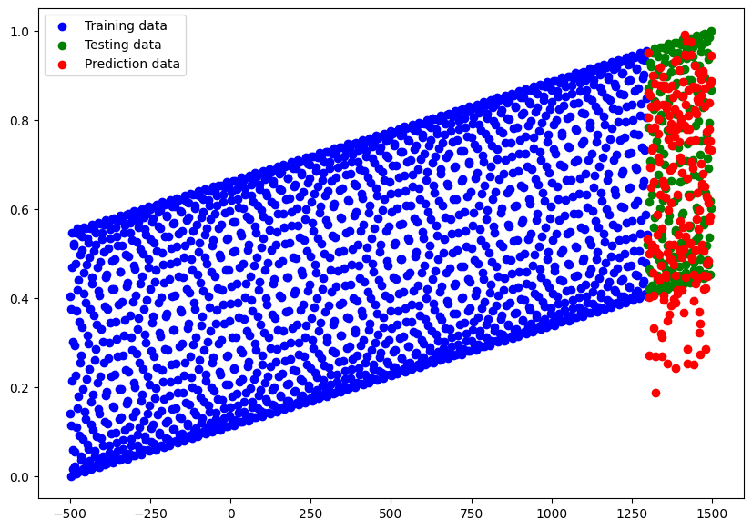

```python
y_scaled_preds12 = model.predict(X_test)

plot_predictions(X_train, y_scaled_train, X_test, y_scaled_test, y_scaled_preds12)
```

Let's visualize of graph on how it improves by epoch.

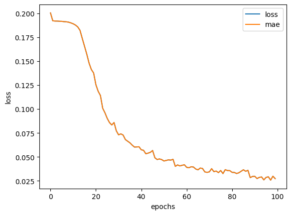

```python
# Create improvement graph by epoch
pd.DataFrame(history.history).plot()
plt.ylabel('loss')
plt.xlabel('epochs')
```

Let's see how well the model improves if we now increase epochs till 1,000.

```python
from tensorflow.keras.layers import Dense, PReLU, Activation, Lambda

# Set seed
tf.random.set_seed(35)

# Custom Sinusoidal Activation Function
def sinusoidal(x):
    return tf.sin(x)

# Create the model
model = tf.keras.Sequential([
    Dense(16), Lambda(sinusoidal),
    Dense(32), Lambda(sinusoidal),
    Dense(64), Lambda(sinusoidal),
    Dense(128), Lambda(sinusoidal),
    Dense(256), Lambda(sinusoidal),
    Dense(128), Lambda(sinusoidal),
    tf.keras.layers.Dense(128), PReLU(),
    Dense(128), Activation('softplus'),
    Dense(64), Lambda(sinusoidal),
    tf.keras.layers.Dense(64), PReLU(),
    Dense(64), Activation('softplus'),
    Dense(32), Activation('softplus'),
    tf.keras.layers.Dense(16), PReLU(),
    Dense(16), Lambda(sinusoidal),
    Dense(16), Activation('softplus'),
    Dense(1)
])

# Compile the model
model.compile(
    loss=tf.keras.losses.mae,
    optimizer=tf.keras.optimizers.Adam(learning_rate=0.0001),
    metrics=['mae']
)

# Fit the model
history = model.fit(tf.expand_dims(X_train, axis=-1), y_scaled_train, epochs=1000)
```

```
57/57 ━━━━━━━━━━━━━━━━━━━━ 11s 8ms/step - loss: 0.2066 - mae: 0.2066
57/57 ━━━━━━━━━━━━━━━━━━━━ 1s 9ms/step - loss: 0.1959 - mae: 0.1959
57/57 ━━━━━━━━━━━━━━━━━━━━ 0s 7ms/step - loss: 0.1956 - mae: 0.1956
57/57 ━━━━━━━━━━━━━━━━━━━━ 0s 7ms/step - loss: 0.1951 - mae: 0.1951
57/57 ━━━━━━━━━━━━━━━━━━━━ 0s 8ms/step - loss: 0.1938 - mae: 0.1938
57/57 ━━━━━━━━━━━━━━━━━━━━ 0s 7ms/step - loss: 0.1921 - mae: 0.1921
57/57 ━━━━━━━━━━━━━━━━━━━━ 0s 8ms/step - loss: 0.1897 - mae: 0.1897
57/57 ━━━━━━━━━━━━━━━━━━━━ 0s 8ms/step - loss: 0.1929 - mae: 0.1929
57/57 ━━━━━━━━━━━━━━━━━━━━ 0s 7ms/step - loss: 0.1904 - mae: 0.1904
57/57 ━━━━━━━━━━━━━━━━━━━━ 1s 8ms/step - loss: 0.1879 - mae: 0.1879
57/57 ━━━━━━━━━━━━━━━━━━━━ 0s 7ms/step - loss: 0.1872 - mae: 0.1872
57/57 ━━━━━━━━━━━━━━━━━━━━ 0s 8ms/step - loss: 0.1851 - mae: 0.1851
57/57 ━━━━━━━━━━━━━━━━━━━━ 0s 7ms/step - loss: 0.1849 - mae: 0.1849
57/57 ━━━━━━━━━━━━━━━━━━━━ 0s 7ms/step - loss: 0.1843 - mae: 0.1843
57/57 ━━━━━━━━━━━━━━━━━━━━ 0s 8ms/step - loss: 0.1834 - mae: 0.1834
57/57 ━━━━━━━━━━━━━━━━━━━━ 0s 7ms/step - loss: 0.1823 - mae: 0.1823
57/57 ━━━━━━━━━━━━━━━━━━━━ 0s 7ms/step - loss: 0.1819 - mae: 0.1819
57/57 ━━━━━━━━━━━━━━━━━━━━ 0s 8ms/step - loss: 0.1806 - mae: 0.1806
57/57 ━━━━━━━━━━━━━━━━━━━━ 0s 7ms/step - loss: 0.1793 - mae: 0.1793
57/57 ━━━━━━━━━━━━━━━━━━━━ 0s 7ms/step - loss: 0.1776 - mae: 0.1776
57/57 ━━━━━━━━━━━━━━━━━━━━ 0s 7ms/step - loss: 0.1751 - mae: 0.1751
57/57 ━━━━━━━━━━━━━━━━━━━━ 1s 8ms/step - loss: 0.1711 - mae: 0.1711
57/57 ━━━━━━━━━━━━━━━━━━━━ 1s 12ms/step - loss: 0.1603 - mae: 0.1603
57/57 ━━━━━━━━━━━━━━━━━━━━ 1s 8ms/step - loss: 0.1281 - mae: 0.1281
57/57 ━━━━━━━━━━━━━━━━━━━━ 0s 8ms/step - loss: 0.1176 - mae: 0.1176
57/57 ━━━━━━━━━━━━━━━━━━━━ 0s 7ms/step - loss: 0.1006 - mae: 0.1006
57/57 ━━━━━━━━━━━━━━━━━━━━ 0s 7ms/step - loss: 0.0910 - mae: 0.0910
57/57 ━━━━━━━━━━━━━━━━━━━━ 1s 8ms/step - loss: 0.0896 - mae: 0.0896
57/57 ━━━━━━━━━━━━━━━━━━━━ 0s 8ms/step - loss: 0.0899 - mae: 0.0899
57/57 ━━━━━━━━━━━━━━━━━━━━ 0s 8ms/step - loss: 0.0832 - mae: 0.0832
57/57 ━━━━━━━━━━━━━━━━━━━━ 0s 7ms/step - loss: 0.0825 - mae: 0.0825
57/57 ━━━━━━━━━━━━━━━━━━━━ 0s 7ms/step - loss: 0.0763 - mae: 0.0763
57/57 ━━━━━━━━━━━━━━━━━━━━ 0s 7ms/step - loss: 0.0765 - mae: 0.0765
57/57 ━━━━━━━━━━━━━━━━━━━━ 0s 7ms/step - loss: 0.0778 - mae: 0.0778
57/57 ━━━━━━━━━━━━━━━━━━━━ 1s 8ms/step - loss: 0.0741 - mae: 0.0741
57/57 ━━━━━━━━━━━━━━━━━━━━ 0s 7ms/step - loss: 0.0736 - mae: 0.0736
57/57 ━━━━━━━━━━━━━━━━━━━━ 0s 7ms/step - loss: 0.0678 - mae: 0.0678
57/57 ━━━━━━━━━━━━━━━━━━━━ 0s 7ms/step - loss: 0.0688 - mae: 0.0688
57/57 ━━━━━━━━━━━━━━━━━━━━ 0s 7ms/step - loss: 0.0682 - mae: 0.0682
57/57 ━━━━━━━━━━━━━━━━━━━━ 0s 7ms/step - loss: 0.0668 - mae: 0.0668
```

[output cut: 945 more lines]

```
57/57 ━━━━━━━━━━━━━━━━━━━━ 1s 8ms/step - loss: 0.0259 - mae: 0.0259
57/57 ━━━━━━━━━━━━━━━━━━━━ 1s 8ms/step - loss: 0.0267 - mae: 0.0267
57/57 ━━━━━━━━━━━━━━━━━━━━ 1s 10ms/step - loss: 0.0248 - mae: 0.0248
57/57 ━━━━━━━━━━━━━━━━━━━━ 0s 7ms/step - loss: 0.0239 - mae: 0.0239
57/57 ━━━━━━━━━━━━━━━━━━━━ 1s 7ms/step - loss: 0.0225 - mae: 0.0225
57/57 ━━━━━━━━━━━━━━━━━━━━ 1s 13ms/step - loss: 0.0261 - mae: 0.0261
57/57 ━━━━━━━━━━━━━━━━━━━━ 1s 8ms/step - loss: 0.0277 - mae: 0.0277
57/57 ━━━━━━━━━━━━━━━━━━━━ 1s 9ms/step - loss: 0.0205 - mae: 0.0205
57/57 ━━━━━━━━━━━━━━━━━━━━ 1s 9ms/step - loss: 0.0189 - mae: 0.0189
57/57 ━━━━━━━━━━━━━━━━━━━━ 1s 8ms/step - loss: 0.0173 - mae: 0.0173
57/57 ━━━━━━━━━━━━━━━━━━━━ 1s 9ms/step - loss: 0.0136 - mae: 0.0136
57/57 ━━━━━━━━━━━━━━━━━━━━ 1s 8ms/step - loss: 0.0138 - mae: 0.0138
57/57 ━━━━━━━━━━━━━━━━━━━━ 1s 8ms/step - loss: 0.0140 - mae: 0.0140
57/57 ━━━━━━━━━━━━━━━━━━━━ 1s 8ms/step - loss: 0.0137 - mae: 0.0137
57/57 ━━━━━━━━━━━━━━━━━━━━ 1s 9ms/step - loss: 0.0145 - mae: 0.0145
```

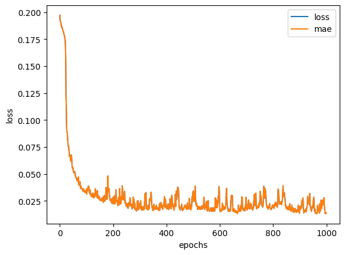

```python
# Create improvement graph by epoch
pd.DataFrame(history.history).plot()
plt.ylabel('loss')
plt.xlabel('epochs')
```

Next, I want to have a look at the details of our model by calling `.summary`.

```python
model.summary()
```

```
Model: "sequential_173"
```

```
┏━━━━━━━━━━━━━━━━━━━━━━━━━━━━━━━━━┳━━━━━━━━━━━━━━━━━━━━━━━━┳━━━━━━━━━━━━━━━┓
┃ Layer (type)                    ┃ Output Shape           ┃       Param # ┃
┡━━━━━━━━━━━━━━━━━━━━━━━━━━━━━━━━━╇━━━━━━━━━━━━━━━━━━━━━━━━╇━━━━━━━━━━━━━━━┩
│ dense_1101 (Dense)              │ (None, 16)             │            32 │
├─────────────────────────────────┼────────────────────────┼───────────────┤
│ lambda_504 (Lambda)             │ (None, 16)             │             0 │
├─────────────────────────────────┼────────────────────────┼───────────────┤
│ dense_1102 (Dense)              │ (None, 32)             │           544 │
├─────────────────────────────────┼────────────────────────┼───────────────┤
│ lambda_505 (Lambda)             │ (None, 32)             │             0 │
├─────────────────────────────────┼────────────────────────┼───────────────┤
│ dense_1103 (Dense)              │ (None, 64)             │         2,112 │
├─────────────────────────────────┼────────────────────────┼───────────────┤
│ lambda_506 (Lambda)             │ (None, 64)             │             0 │
├─────────────────────────────────┼────────────────────────┼───────────────┤
│ dense_1104 (Dense)              │ (None, 128)            │         8,320 │
├─────────────────────────────────┼────────────────────────┼───────────────┤
│ lambda_507 (Lambda)             │ (None, 128)            │             0 │
├─────────────────────────────────┼────────────────────────┼───────────────┤
│ dense_1105 (Dense)              │ (None, 256)            │        33,024 │
├─────────────────────────────────┼────────────────────────┼───────────────┤
│ lambda_508 (Lambda)             │ (None, 256)            │             0 │
├─────────────────────────────────┼────────────────────────┼───────────────┤
│ dense_1106 (Dense)              │ (None, 128)            │        32,896 │
├─────────────────────────────────┼────────────────────────┼───────────────┤
│ lambda_509 (Lambda)             │ (None, 128)            │             0 │
├─────────────────────────────────┼────────────────────────┼───────────────┤
│ dense_1107 (Dense)              │ (None, 128)            │        16,512 │
├─────────────────────────────────┼────────────────────────┼───────────────┤
│ p_re_lu_177 (PReLU)             │ (None, 128)            │           128 │
├─────────────────────────────────┼────────────────────────┼───────────────┤
│ dense_1108 (Dense)              │ (None, 128)            │        16,512 │
├─────────────────────────────────┼────────────────────────┼───────────────┤
│ activation_197 (Activation)     │ (None, 128)            │             0 │
├─────────────────────────────────┼────────────────────────┼───────────────┤
│ dense_1109 (Dense)              │ (None, 64)             │         8,256 │
├─────────────────────────────────┼────────────────────────┼───────────────┤
│ lambda_510 (Lambda)             │ (None, 64)             │             0 │
├─────────────────────────────────┼────────────────────────┼───────────────┤
│ dense_1110 (Dense)              │ (None, 64)             │         4,160 │
```

[output cut: 10 more lines]

```
├─────────────────────────────────┼────────────────────────┼───────────────┤
│ dense_1113 (Dense)              │ (None, 16)             │           528 │
├─────────────────────────────────┼────────────────────────┼───────────────┤
│ p_re_lu_179 (PReLU)             │ (None, 16)             │            16 │
├─────────────────────────────────┼────────────────────────┼───────────────┤
│ dense_1114 (Dense)              │ (None, 16)             │           272 │
├─────────────────────────────────┼────────────────────────┼───────────────┤
│ lambda_511 (Lambda)             │ (None, 16)             │             0 │
├─────────────────────────────────┼────────────────────────┼───────────────┤
│ dense_1115 (Dense)              │ (None, 16)             │           272 │
├─────────────────────────────────┼────────────────────────┼───────────────┤
│ activation_200 (Activation)     │ (None, 16)             │             0 │
├─────────────────────────────────┼────────────────────────┼───────────────┤
│ dense_1116 (Dense)              │ (None, 1)              │            17 │
└─────────────────────────────────┴────────────────────────┴───────────────┘
```

```
 Total params: 389,717 (1.49 MB)
```

```
 Trainable params: 129,905 (507.44 KB)
```

```
 Non-trainable params: 0 (0.00 B)
```

```
 Optimizer params: 259,812 (1014.89 KB)
```

Quite a hefty ML model aye?

There's a few takeaways from the amount of testing I've done to perfect the neural network as much as possible:

1. `softplus` Seems to work very well as a sort of outputter/congregator of data after it's been processing and been through other layers. It acts as a funnel of some sort, making it more digestible for the ML model.
2. There's sort of a revolving pattern between `Sinusoidal`, `PreLU` and `softplus`, where they can really work cohesively together.
3. Going by exponents of 2 seem to yield better results (2, 4, 8, 16, 32, etc.). My theories is mostly because each nodes are connected by 2 other nodes, either in front of them, or behind them. Making it better for processing.
4. There seems to be an interesting point in `Sinusoidal`, where there's this exponent increase, and square rooting decrease on the first half of the model, allowing it to be more capable of learning patterns in our data.
5. It makes sense that Sinusoidal does most of the heavy lifting, due to most of it's patern processing is based on sine curves, which is what we utilized in creating our data.

Finally, let's see how well the model has performed on the data.

```
7/7 ━━━━━━━━━━━━━━━━━━━━ 9s 579ms/step
7/7 ━━━━━━━━━━━━━━━━━━━━ 34s 278ms/step - loss: 0.1255 - mae: 0.1255
```

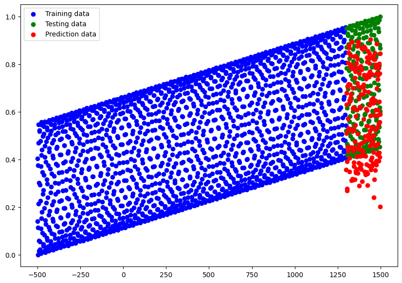

```python
# Our final model
final_model = model.predict(X_test)

final_model_loss, final_model_mae = model.evaluate(X_test, y_scaled_test), plot_predictions(X_train, y_scaled_train, X_test, y_scaled_test, final_model)
```

```python
# save the model
model.save('best_model_for_this_task.keras')
```

```python
!dir best_model_for_this_task.keras
```

```
 Volume in drive F is Extreme SSD
 Volume Serial Number is CE95-62AC

 Directory of f:\main shit\Code stuffz\tensorflow ztm\01 notebook

21/01/2025  01:14 pm         1,688,258 best_model_for_this_task.keras
               1 File(s)      1,688,258 bytes
               0 Dir(s)  1,221,106,597,888 bytes free
```